# Lab 5: Summary Notebook

Group Members:

- Parker Brown
- Suma Chackola
- Chris Peters
- Oliver Raney

# Emitter Localization using Q-Learning Optimized Sensor Positioning

By: Parker Brown, Suma Chackola, Chris Peters, Oliver Raney

## Iteration 1:

The RSS is found by the Friis free space equation: $$ \text{RSS}_{\text{i}} (dBm) = -20 \times \log_{10} \left(\frac{{4 \pi \times R_i f}}{{c}}\right) + \text{P}_{\text{e}} $$ where:

- $R_i$ is the distance from the emitter to the sensor in m
- $f$ is the emitter operational frequency in Hz, which is 5 GHz
- $c$ is the signal propagation speed, which is $3\times 10^8$ m/s in a vacuum
- $P_e$ is the emitter output power in dBm

*Success Metric*

The success of each iteration is measured by the decreasing radius of the error ellipse and the reduction in the Euclidean distance between the center of this ellipse and the true target position. The system iterates until it reaches a predefined number of steps, a time limit, or the emitter is within a specified radius, indicating successful localization. We keep this metric the same across all iterations in order to maintain a fair comparison of success.

Additionally, the system's robustness and accuracy will be tested through Monte Carlo simulations with a series of initial positions to validate the localization estimates against the true target location. Each iteration will be conducted in 2 dimensional environments, where mostly zero-mean Gaussian-distributed error is added to the TOA, $\epsilon_t$ with $\sigma^2 = 10 ns$, to the individual sensor positions, with $\epsilon_x, \epsilon_y, \epsilon_z$ having $\sigma^2 = 2 cm$, including additional time delay due to multipath, with $\epsilon_n$ as $\sigma^2 = 10 ns$, and including a corresponding RSS noise value for multipath & signal fading, $\epsilon_p$ as $\mu = 3 dB$ and $\sigma^2 = 5 dB$.

```python
#!pip install gym
```

```python
# Import Necessary Functions
import numpy as np
import matplotlib.pyplot as plt
from pettingzoo import AECEnv
from gym.spaces import Discrete, Box
from itertools import combinations
```

```python
# LOCA Algorithm (Ralph Schmidt, 1972, https://ieeexplore.ieee.org/document/4103057) is below
# This LOCA Function enumerates all solutions - assuming at least 4 sensors for 2D

def LOCAfun_allcombs_2D(P1, S1):
    i_soln = 0
    xyWLS_comb = []
    for pqty in range(4, P1.shape[0] + 1):  # Count number of sensors
        for pmax in range(4, P1.shape[0] + 1):  # Count number of sensors
            prange = np.arange(1, pmax + 1)  # Use entire range of sensors for nchoosek calc
            combels = np.array(list(combinations(prange, pqty)))  # All combs with pqty sensors
            for combqty in range(combels.shape[0]):  # Number of rows in combinations
                els = combels.shape[1]
                P = np.zeros((els, 2))
                P[0:els, :] = P1[combels[combqty, 0:els] - 1, :]
                S = S1[combels[combqty, 0:els] - 1]

                N = P.shape[0]
                combs = np.math.comb(N, 3)  # N-choose-3

                cl = 3e8
                xis, yis = P[:, 0], P[:, 1]
                sumdijk = np.zeros(combs)
                Am = np.zeros(combs)
                Bm = np.zeros(combs)
                Dm = np.zeros(combs)
                mc = np.zeros((combs, 3))
                ai = np.zeros(N)
                dijk = np.zeros((N, N))

                for i in range(N):
                    ai[i] = np.sqrt(xis[i]**2 + yis[i]**2)
                    for j in range(N):
                        dijk[i, j] = cl * (S[j] - S[i])

                m = 0
                for i in range(N):
                    for j in range(i + 1, N):
                        for k in range(j + 1, N):
                            sumdijk[m] = dijk[i, j] + dijk[j, k] + dijk[k, i]
                            Am[m] = xis[i] * dijk[j, k] + xis[j] * dijk[k, i] + xis[k] * (dijk[i, j] - sumdijk[m])
                            Bm[m] = yis[i] * dijk[j, k] + yis[j] * dijk[k, i] + yis[k] * (dijk[i, j] - sumdijk[m])
                            Dm[m] = 0.5 * (dijk[i, j] * dijk[j, k] * dijk[k, i] + ai[i]**2 * dijk[j, k] +
                                           ai[j]**2 * dijk[k, i] + ai[k]**2 * (dijk[i, j] - sumdijk[m]))
                            mc[m] = [i, j, k]
                            m += 1

                LineAmBmDm = np.column_stack((Am, Bm, Dm))
                lines = LineAmBmDm.shape[0]
                sqWLS = np.zeros(lines)
                AmWLS = np.zeros(lines)
                BmWLS = np.zeros(lines)
                DmWLS = np.zeros(lines)

                for i in range(lines):
                    sqWLS[i] = np.sqrt(Am[i]**2 + Bm[i]**2)
                    AmWLS[i] = Am[i] / sqWLS[i]
                    BmWLS[i] = Bm[i] / sqWLS[i]
                    DmWLS[i] = Dm[i] / sqWLS[i]

                xyWLS = np.linalg.lstsq(np.column_stack((AmWLS, BmWLS)), DmWLS, rcond=None)[0]
                xyWLS_comb.append(xyWLS)
                i_soln += 1

    LOCASoln = np.array(xyWLS_comb)
    return LOCASoln
```

```python
from matplotlib.patches import Ellipse
def calculate_elliptical_CEP(estimated_positions):
    mean_x = np.mean(estimated_positions[:, 0])
    mean_y = np.mean(estimated_positions[:, 1])
    std_x = np.std(estimated_positions[:, 0])
    std_y = np.std(estimated_positions[:, 1])
    median_x = np.median(estimated_positions[:, 0])
    median_y = np.median(estimated_positions[:, 1])
    mad_x = np.median(np.abs(estimated_positions[:, 0] - median_x))
    mad_y = np.median(np.abs(estimated_positions[:, 1] - median_y))
    return std_x, std_y, mean_x, mean_y, median_x, median_y, mad_x, mad_y
```

```python
# Plotting Tools

# Function to plot drone locations
def plot_locations(initial_locations, final_locations, target_location, numsteps):
    std_x, std_y, mean_x, mean_y, median_x, median_y, mad_x, mad_y = calculate_elliptical_CEP(estimated_positions)
    # Plot circle using std deviations of x & y values
    radius = np.sqrt(mad_x**2 + mad_y**2)
    mean_cep_legend = f'$\mu$ CEP ({np.round(radius,2)})'
    circle_mean = Ellipse((median_x, median_y), 2*radius, 2*radius, edgecolor='green', facecolor='none', linestyle='-', linewidth=2, label=mean_cep_legend)
    #plt.gca().add_patch(circle_mean)

    fig, axs = plt.subplots(3, 1, figsize=(6, 16))

    # Plot initial locations
    for i, drone in enumerate(initial_locations):
        axs[0].scatter(drone[0], drone[1], color='blue')
        axs[0].text(drone[0], drone[1], f'UAS {i+1}', fontsize=12, verticalalignment='bottom', horizontalalignment='right')
    axs[0].scatter(target_location[0, 0], target_location[0, 1], color='red', label='Target')
    axs[0].text(target_location[0][0], target_location[0][1], f'Target', fontsize=12, verticalalignment='bottom', horizontalalignment='right')

    axs[0].set_title('Initial UAS Positions')
    axs[0].set_xlabel('X')
    axs[0].set_ylabel('Y')
    axs[0].set_ylim(-1000, 2000)
    axs[0].set_xlim(-1000, 2000)
    #axs[0].legend()
    axs[0].grid(True)

    # Plot drone positions for each time step

    for i in range(env.num_drones):
        positions_x = [position[0] for position in env.drone_trajectory[i]]
        positions_y = [position[1] for position in env.drone_trajectory[i]]
        axs[1].plot(positions_x, positions_y, label=f'UAS {i+1}')
    axs[1].scatter(target_location[0, 0], target_location[0, 1], color='red', marker='o', s=100, edgecolors='red', facecolors='none', linewidths=2, label='Target Location')

    cen_x = [cen[0] for cen in env.centroids]
    cen_y = [cen[1] for cen in env.centroids]
    axs[1].plot(cen_x,cen_y, label=f'Centroid Evolution', alpha=0.5)
    #for i, drone in enumerate(initial_locations):
        #axs[1].scatter(drone[0], drone[1], color='blue')
    #    axs[1].text(drone[0], drone[1], f'UAS {i+1}', fontsize=12, verticalalignment='bottom', horizontalalignment='right')
    #for i, drone in enumerate(final_locations):
    for i, drone in enumerate(final_locations):
        axs[1].scatter(drone[0], drone[1], color='blue', marker='d')

    axs[1].scatter(final_locations[0][0], final_locations[0][1], color='blue', marker='d',label='Final Positions')
    #    axs[1].text(drone[0], drone[1], f'UAS {i+1}', fontsize=12, verticalalignment='bottom', horizontalalignment='right')

    #    circle_mean = Ellipse((median_x, median_y), 2*radius, 2*radius, edgecolor='green', facecolor='none', linestyle='-', linewidth=2, label=mean_cep_legend)
    #axs[1].add_patch(circle_mean)
    axs[1].scatter(env.centroids[-1][0], env.centroids[-1][1], color='black', marker='p',label='Final Estimate')


    axs[1].text(target_location[0][0], target_location[0][1], f'Target', fontsize=12, verticalalignment='bottom', horizontalalignment='right')


    #axs[1].scatter(env.target_location[0, 0], env.target_location[0, 1], color='red', label='Target')
    axs[1].set_xlabel('X')
    axs[1].set_ylabel('Y')
    axs[1].set_title(f"UAS Positions & Estimates, Convergence Steps: {numsteps}")
    axs[1].set_ylim(-2000, 2000)
    axs[1].set_xlim(-2000, 2000)
    axs[1].legend()
    axs[1].grid(True)

    # Plot final locations
    for i, drone in enumerate(final_locations):
        axs[2].scatter(drone[0], drone[1], color='blue')
        axs[2].text(drone[0], drone[1], f'UAS {i+1}', fontsize=12, verticalalignment='bottom', horizontalalignment='right')
    axs[2].scatter(target_location[0, 0], target_location[0, 1], color='red', label='Target')
    axs[2].text(target_location[0][0], target_location[0][1], f'Target', fontsize=12, verticalalignment='bottom', horizontalalignment='right')
    axs[2].set_title(f"Final UAS Positions, Convergence Steps: {numsteps}")
    axs[2].set_xlabel('X')
    axs[2].set_ylabel('Y')
    axs[2].set_ylim(-1000, 2000)
    axs[2].set_xlim(-1000, 2000)
    #axs[1].legend()
    axs[2].grid(True)

    plt.tight_layout()
    plt.show()
```

```python
# Define Errors
stdev_rss_err = 5 # StDev for Multipath & Fading contribution in dB
mean_rss_err = 3 # Mean RSS Error
stdev_pos_err = 0.02 # StDev for Positioning Error in m
stdev_time_err = 10*1e-9 # StDev for Local Timing Inaccuracy in s

r0loc = 25
SNR0 = 141
Ts = 1e-6
Bw = 2e6
ascale = (3/2)*1/(2*np.pi**2*(5e9)*Ts*(Bw**2))

max_dist = 1500

calpha = 23;
galpha = 0.26;
csigma = 5.5;
gsigma = 0.35;

def add_errs(loc,toa):
    poserr = np.array([[np.random.normal(loc=0, scale = stdev_pos_err),np.random.normal(loc=0, scale = stdev_pos_err)]])
    location_err = loc + poserr # adding error

    # Some extra calcs for clock err
    riclock = toa*(3e8)
    SNRi = SNR0*(r0loc**2)/(((riclock)**2)+0.00001)
    varti = (ascale*riclock**2)/(SNR0*r0loc**2)

    # Some extra calcs for environmental delay due to multipath
    alpha_s = calpha*(riclock**galpha)
    sigma_s = csigma*(riclock**gsigma)
    env_delay = (alpha_s + np.random.normal(loc=0, scale = sigma_s))/(1e9)
    env_delay_fact = 0.5

    toa_err = toa + abs(np.random.normal(loc=0, scale = stdev_time_err))+ \
    abs(np.random.normal(loc=0, scale = np.sqrt(varti))) + env_delay_fact*env_delay

    #return loc, toa
    return location_err, toa_err
```

```python
class DroneEnv(AECEnv):
    def __init__(self, num_drones):
        super().__init__()
        self.width = 2000
        self.height = self.width
        self.max_steps = 1000
        self.current_step = 0
        self.LOCASoln = []

        self.movements = np.array([[-5,5], [0,5], [5,5], [-5,0], [0,0], [5,0], [-5,-5], [0,-5], [5,-5]])
        #self.drone_status = [['active'] for _ in range(num_drones)]

        # Currently setting this to fixed value to compare approaches
        self.targ_loc2 = np.array([[350,  350]])
        self.target_location = self.targ_loc2.copy()

        # Uncomment this line if we want to vary target from run-to-run
        #self.target_location = np.random.randint(50, self.width, size=(1, 2))

        # Currently setting this to fixed value to compare approaches
        self.num_drones = num_drones

        #trial run with fixed positions.
        #self.initial_drones_location2 = np.array(([[700, 100], [271, 478],[300,  75],[650, 650], [191, 701], [ 96, 195]]))
        self.initial_drones_location = np.random.randint(50, self.width, size=(self.num_drones, 2))

        self.drones_location =  self.initial_drones_location.copy()

        self.initial_loc = self.initial_drones_location.copy()

        self.target_power = 10

        power_init = -1 * 20 * np.log10((4 * np.pi * 2*self.width * 5e9) / 3e8) +  self.target_power
        self.signal_strength = np.zeros(self.num_drones) + power_init
        self.drone_trajectory = [[] for _ in range(num_drones)]  # List to store trajectories for each drone

        self.metadata = {'render.modes': ['human']}

        self.action_space = Discrete(len(self.movements))  # Discrete action space
        #self.action_space = Discrete(9)  # Discrete action space

        self.observation_space = Box(low=0, high=self.width, shape=(5,), dtype=np.float32)


        # Initialize Q-tables for each agent
        self.q_tables = [np.zeros((self.observation_space.shape[0], self.action_space.n)) for _ in range(num_drones)]

        self.alpha = 0.1  # Learning rate
        self.gamma = 0.9  # Discount factor
        self.epsilon = 0.1  # Epsilon for epsilon-greedy action selection

        self.loca_soln_avg =  np.random.randint(50, self.width, size=(1, 2))

        initial_distances = np.linalg.norm(self.target_location - self.initial_loc, axis=1)
        toas = initial_distances/(3e8) # Convert Distance to Time

        drones_location_err = np.zeros((self.num_drones,2))

        # Calculate LOCA Estimate
        for i in range(self.num_drones): # Add errors
            drones_location_err[i], toas[i] = add_errs(self.initial_loc[i],toas[i])

        LOCASoln = LOCAfun_allcombs_2D(drones_location_err, toas)
        std_x, std_y, mean_x, mean_y, median_x, median_y, mad_x, mad_y = calculate_elliptical_CEP(LOCASoln)
        self.localization_est = np.array([[median_x,median_y]])
        self.loca_err =  np.linalg.norm(self.localization_est - self.target_location, axis=1)
        self.LOCASoln = LOCASoln.copy()
        cep_radius = np.sqrt(mad_x**2 + mad_y**2)
        self.cep_radius_after = cep_radius.copy()
        self.old_locs = drones_location_err
        self.centroids = []




    def observe(self, agent):
        return self.signal_strength[agent]

    def step(self, action):
        #if DEBUG: print(action)
        self.current_step += 1

        cp_prev = np.round(self.cep_radius_after,2)

        min_cep = 2
        ds = np.abs(np.round(((cp_prev-min_cep)/min_cep),2))

        self.movements = np.array([[0, ds], [0, -1*ds], [ds, 0], [-1*ds, 0], [0, 0], [ds,ds], [ds,-1*ds], [-1*ds,-1*ds], [-1*ds,-1*ds]])

        drones_location_err = np.zeros((self.num_drones,2))
        toas = np.zeros(self.num_drones)


        distances_before_action = np.linalg.norm(self.target_location - self.drones_location, axis=1)
        toas = distances_before_action/(3e8) # Convert Distance to Time

        # Calculate LOCA Estimate
        for i in range(self.num_drones):
            drones_location_err[i], toas[i] = add_errs(self.drones_location[i],toas[i])

        LOCASoln = LOCAfun_allcombs_2D(drones_location_err, toas)
        std_x, std_y, mean_x, mean_y, median_x, median_y, mad_x, mad_y = calculate_elliptical_CEP(LOCASoln)
        localization_est_before = np.array([median_x,median_y])
        loca_err =  np.linalg.norm(localization_est_before - self.target_location, axis=1)

        # Calculate Power Before
        power_before = np.zeros(self.num_drones)  # Initialize power_before array
        for i in range(self.num_drones):
            distance = np.linalg.norm(self.target_location - self.drones_location[i])
            if distance == 0:
                received_power = self.target_power
            else:
                received_power = -1 * 20 * np.log10((4 * np.pi * distance * 5e9) / 3e8) + self.target_power

            # value for random error in received power to account for multipath & fading
            rss_err = abs(np.random.normal(loc=mean_rss_err, scale = stdev_rss_err))
            self.signal_strength[i] = received_power - rss_err
            power_before[i] = received_power  # Store received power in the array

        for i, act in enumerate(action):
            movement = self.movements[act]
            self.drones_location[i] =  self.drones_location[i]+movement
            self.drone_trajectory[i].append(self.drones_location[i].copy())#


        distances_after_action = np.linalg.norm(self.target_location - self.drones_location, axis=1)
        toas = distances_after_action/(3e8) # Convert Distance to Time

        # Calculate LOCA Estimate After Action
        for i in range(self.num_drones):
            drones_location_err[i], toas[i] = add_errs(self.drones_location[i],toas[i])

        self.LOCASoln = LOCAfun_allcombs_2D(drones_location_err, toas) #locasoln_after
        std_x, std_y, mean_x, mean_y, median_x, median_y, mad_x, mad_y = calculate_elliptical_CEP(self.LOCASoln)

        #cep_radius_after = np.sqrt(std_x**2 + std_y**2)
        cep_radius_after = np.sqrt(mad_x**2 + mad_y**2)
        self.totaldistmoved = np.sum(np.sqrt(np.sum((drones_location_err-self.old_locs)**2, axis=1)))

        self.localization_est_after = np.array([median_x,median_y])
        self.loca_err =  np.linalg.norm(self.localization_est_after - self.target_location, axis=1)
        self.centroids.append(self.localization_est_after.copy())

        # Caclulate Power After Action
        power_after = np.zeros(self.num_drones)  # Initialize power_after array
        for i in range(self.num_drones):
            distance = np.linalg.norm(self.target_location - self.drones_location[i])
            if distance == 0:
                received_power = self.target_power
            else:
                received_power = -1 * 20 * np.log10((4 * np.pi * distance * 5e9) / 3e8) + self.target_power

            # value for random error in received power to account for multipath & fading
            rss_err = abs(np.random.normal(loc=mean_rss_err, scale = stdev_rss_err))

            self.signal_strength[i] =  received_power - rss_err
            power_after[i] = received_power  # Store received power in the array

        # Rewards

        rewards = np.where(power_after > power_before, 1, -1)

        # Check for termination conditions

        # Assign a threshold for max power: Assume 60 meters from 10dBm emitter
        target_power_threshold = -1 * 20 * np.log10((4 * np.pi * 60 * 5e9) / 3e8) + self.target_power

        done_max_steps = self.current_step >= self.max_steps
        done_target_CEP = cep_radius_after <= min_cep
        done = done_max_steps or done_target_CEP
        if done:
           # if DEBUG: print('Final LOCA Target Estimate: ', np.round(localization_est_after,2))
           # if DEBUG: print('Final LOCA Error (m): ', np.round(loca_err,2))
            self.LOCASoln = LOCAfun_allcombs_2D(drones_location_err, toas)

        return self.signal_strength, rewards, done, self.LOCASoln, {}

    def reset(self):
        self.initial_loc =  np.random.randint(50, self.width, size=(self.num_drones, 2))
        self.drones_location = self.initial_loc.copy()#np.random.randint(0, self.width, size=(self.num_drones, 2))
        self.signal_strength = np.zeros(self.num_drones) - 200
        self.current_step = 0
        power_init = -1 * 20 * np.log10((4 * np.pi * 2*self.width * 5e9) / 3e8) +  self.target_power
        self.signal_strength = np.zeros(self.num_drones) + power_init
        self.q_tables = [np.zeros((self.observation_space.shape[0], self.action_space.n)) for _ in range(num_drones)]

        self.loca_soln_avg =  np.random.randint(50, self.width, size=(1, 2))
        initial_distances = np.linalg.norm(self.target_location - self.initial_loc, axis=1)
        toas = initial_distances/(3e8) # Convert Distance to Time
        drones_location_err = np.zeros((self.num_drones,2))

        # Calculate LOCA Estimate
        for i in range(self.num_drones): # Add errors
            drones_location_err[i], toas[i] = add_errs(self.initial_loc[i],toas[i])

        LOCASoln = LOCAfun_allcombs_2D(drones_location_err, toas)
        std_x, std_y, mean_x, mean_y, median_x, median_y, mad_x, mad_y = calculate_elliptical_CEP(LOCASoln)

        #cep_radius = np.sqrt(std_x**2 + std_y**2)
        cep_radius = np.sqrt(mad_x**2 + mad_y**2)
       #print("Initial CEP Radius", np.round(cep_radius))
        self.localization_est = np.array([[median_x,median_y]])
        self.loca_err =  np.linalg.norm(self.localization_est - self.target_location, axis=1)
        self.LOCASoln = LOCASoln.copy()
        self.cep_radius_after = cep_radius.copy()


        for i in range(self.num_drones):
            self.drone_trajectory[i] = [np.copy(self.drones_location[i])]  # Reset drone trajectory
        return self.signal_strength

    def render(self, mode='human'):
        pass

    def update_q_table(self, agent, state, action, reward, next_state):
        old_q_value = self.q_tables[agent][state, action]
        next_max_q_value = np.max(self.q_tables[agent][next_state])
        new_q_value = old_q_value + self.alpha * (reward + self.gamma * next_max_q_value - old_q_value)
        self.q_tables[agent][state, action] = new_q_value

    def choose_action(self, agent, state):
        if np.random.rand() < self.epsilon:
            #if DEBUG: print("Exploration")
            #action_out = np.random.randint(self.action_space.n) % 9
            action_out = np.random.randint(self.action_space.n) % len(self.movements)
            return  action_out # Exploration
        else:
            #if DEBUG: print("Exploitation")
            #action_out = np.argmax(self.q_tables[agent][state]) % 9
            action_out = np.argmax(self.q_tables[agent][state]) % len(self.movements)
            return action_out  # Exploitation

    def convert_state_to_int(self, state):
        # Use modulo operation to ensure the state representation falls within the valid range
        npsst = np.sum(state)
        if npsst > 10000: npsst = 10000
        elif npsst < -10000: npsst = -10000
        else: npsst = npsst
        return int(npsst) % self.observation_space.shape[0]
```

```python
import time
start_time = time.time()

# Number of drones (agents)
num_drones = 6
env = DroneEnv(num_drones)
num_simulations = 1
DEBUG=False

ls_numsteps =[]
ls_median_cep =[]
ls_median_err=[]

ls_stddev_x =[]
ls_stddev_y =[]
ls_mean_x=[]
ls_mean_y=[]
ls_med_x=[]
ls_med_y=[]
ls_mad_x=[]
ls_mad_y=[]
ls_totaldistmoved = []
total_rewards_per_simulation = []



for i in range(num_simulations):
    obs = env.reset()
    initial_drones_location = env.drones_location  # Initial drone positions
    total_reward = 0

    if DEBUG: print('Initial LOCA Target Estimate: ', np.round(env.localization_est,2))
    if DEBUG: print('Initial LOCA Error (m): ', np.round(env.loca_err,2))
    initial_LOCA = env.LOCASoln
    initial_distances = np.linalg.norm(env.target_location - env.initial_loc, axis=1)

    for _ in range(1000):
        actions = [env.choose_action(agent, env.convert_state_to_int(env.drones_location[agent])) for agent in range(num_drones)]
        next_obs, rewards, done, LOCASoln, _ = env.step(actions)

        total_reward += np.sum(rewards)

        for agent in range(num_drones):
            state = int(env.convert_state_to_int(env.drones_location[agent]))
            if DEBUG: print(f"Agent {agent + 1} state: {state}")  # Add this line to print the state
            action = actions[agent]
            next_state = env.convert_state_to_int(next_obs[agent])
            reward = rewards[agent]
            env.update_q_table(agent, state, action, reward, next_state)
        obs = next_obs
        if done:
            final_drones_location = env.drones_location
            final_distances = np.linalg.norm(env.target_location - env.drones_location, axis=1)
            final_loc = np.average(env.LOCASoln, axis = 0)

            loca_err =  np.linalg.norm(final_loc - env.target_location, axis = 1)
            estimated_positions = np.array(env.LOCASoln)
            break
    std_x, std_y, mean_x, mean_y, median_x, median_y, mad_x, mad_y = calculate_elliptical_CEP(estimated_positions)
    med_err =  np.linalg.norm(np.array(median_x,median_y)-env.target_location,axis = 1)
    if DEBUG: print("Standard Deviation (x,y):",  np.round(std_x,2),", ",np.round(std_y,2))
    if DEBUG: print("Median Absolute Distance  (x,y):", np.round(mad_x, 2),", ",np.round(mad_y,2))
    if DEBUG: print("Mean Target Estimate (x,y):", np.round(mean_x,2),", ",np.round(mean_y,2))
    if DEBUG: print("Median Target Estimate (x,y):", np.round(median_x, 2),", ",np.round(median_y,2))
    if DEBUG: print("Median Error:", np.round(med_err,2))

    if DEBUG: print('Final LOCA Target Estimate: ', np.round(final_loc,2))
    if DEBUG: print('Final LOCA Error (m): ', np.round(loca_err,2))

    if DEBUG: print("Initial Drone-to-Target Distances\n",np.round(initial_distances,2))
    if DEBUG: print("Final Drone-to-Target Distances\n",np.round(final_distances,2))
    if DEBUG: plot_locations(env.initial_loc, final_drones_location, env.target_location, env.current_step)

    if DEBUG: received_power_initial = -1 * 20 * np.log10((4 * np.pi * initial_distances * 5e9) / 3e8) + env.target_power
    if DEBUG: print("Initial Power",np.round(received_power_initial,2))
    if DEBUG: received_power_final = -1 * 20 * np.log10((4 * np.pi * final_distances * 5e9) / 3e8) + env.target_power
    if DEBUG: print("Final Power",np.round(received_power_final,2))
    if DEBUG: print("Power Improvement",np.round(received_power_final-received_power_initial,2))
    if DEBUG: print("Completion Steps: ", env.current_step)

    #save off values
    ls_numsteps.append(env.current_step)
    ls_median_err.append(med_err[-1])
    ls_median_cep.append(np.sqrt(mad_x**2 + mad_y**2))
    ls_totaldistmoved.append(env.totaldistmoved)
    total_rewards_per_simulation.append(total_reward)


    # Optional:
    ls_stddev_x.append(np.round(std_x, 2))
    ls_stddev_y.append(np.round(std_y, 2))
    ls_med_x.append(np.round(median_x, 2))
    ls_med_y.append(np.round(median_y, 2))
    ls_mean_x.append(np.round(mean_x, 2))
    ls_mean_y.append(np.round(mean_y, 2))
    ls_mad_x.append(np.round(mad_x, 2))
    ls_mad_y.append(np.round(mad_y, 2))


    # Print progress every 25 steps
    if i % 100 == 1:
        current_time = time.time()
        elapsed_time = current_time - start_time
        avg_time_per_step = elapsed_time / i
        estimated_total_time = avg_time_per_step * num_simulations
        estimated_time_remaining = estimated_total_time - elapsed_time

        print(f"Step {i}/{num_simulations}")
        print(f"Time elapsed: {elapsed_time:.2f} seconds")
        print(f"Estimated time to complete: {estimated_time_remaining:.2f} seconds")

    if i == num_simulations:
        print("Done")


#print("Number of Steps: ", ls_numsteps)
#print("Median Error: ", np.round(ls_median_err,2))
#print("Median CEP: ", np.round(ls_median_cep,2))

# print(ls_stddev_x)
# print(ls_stddev_y)
# print(ls_mean_x)
# print(ls_mean_y)
# print(ls_med_x)
# print(ls_med_y)
# print(ls_mad_x)
# print(ls_mad_y)
```

```
Initial Drone-to-Target Distances
 [[1833  958]
 [1176  752]
 [1483  814]
 [ 469  937]
 [ 683  153]
 [1480 1106]]
Final Drone Locations
 [[1343 -261]
 [ 543   14]
 [ 922  386]
 [ 397  191]
 [ 192  476]
 [ 149  964]]
```

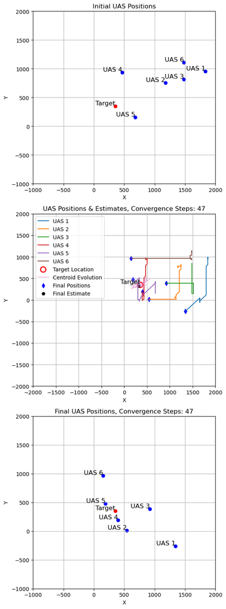

```python
print("Initial Drone-to-Target Distances\n",np.round(env.initial_loc,2))
print("Final Drone Locations\n", env.drones_location)
plot_locations(env.initial_loc, env.drones_location, env.target_location, env.current_step)
```

```python
import pandas as pd

results_df = pd.DataFrame({'Num_Steps': ls_numsteps, 'Median_Error': ls_median_err, 'Median_CEP': ls_median_cep,
                           'Median_X': ls_med_x, 'Median_Y': ls_med_y, 'MAD_X': ls_mad_x, 'MAD_Y': ls_mad_y,
                          'Mean_X': ls_mean_x, 'Mean_Y': ls_mean_y, 'Std_X': ls_stddev_x, 'Std_Y': ls_stddev_y,
                          'Distance_Moved': ls_totaldistmoved, 'TotalReward': total_rewards_per_simulation} )

results_df.to_csv('iter1_results1.csv', index=False)
results_df = pd.read_csv('iter1_results10000_fin.csv')

results_df.describe().style.format("{:.2f}")
```

|  | Num_Steps | Median_Error | Median_CEP | Median_X | Median_Y | MAD_X | MAD_Y | Mean_X | Mean_Y | Std_X | Std_Y | Distance_Moved | TotalReward |
| --- | --- | --- | --- | --- | --- | --- | --- | --- | --- | --- | --- | --- | --- |
| count | 10000.00 | 10000.00 | 10000.00 | 10000.00 | 10000.00 | 10000.00 | 10000.00 | 10000.00 | 10000.00 | 10000.00 | 10000.00 | 10000.00 | 10000.00 |
| mean | 118.00 | 12.74 | 3.19 | 350.04 | 349.27 | 2.06 | 2.28 | 353.59 | 344.83 | 59.79 | 49.37 | 10007.55 | 122.56 |
| std | 121.76 | 45.05 | 105.28 | 33.10 | 63.46 | 63.44 | 84.02 | 719.47 | 684.91 | 1403.12 | 1068.00 | 17378.50 | 251.49 |
| min | 1.00 | 0.00 | 0.02 | -1764.57 | -5138.72 | 0.01 | 0.01 | -14924.57 | -65537.04 | 0.06 | 0.03 | 2864.99 | -1414.00 |
| 25% | 46.00 | 3.31 | 1.00 | 344.82 | 343.92 | 0.53 | 0.58 | 343.97 | 343.26 | 2.60 | 2.67 | 6340.95 | 15.50 |
| 50% | 85.00 | 7.38 | 1.41 | 349.87 | 350.10 | 0.84 | 0.92 | 349.88 | 350.12 | 5.23 | 5.20 | 7431.46 | 76.00 |
| 75% | 146.00 | 14.34 | 1.73 | 355.28 | 356.32 | 1.18 | 1.27 | 356.09 | 357.04 | 12.74 | 12.39 | 9162.02 | 182.00 |
| max | 1000.00 | 2990.46 | 10310.58 | 2169.62 | 790.22 | 6141.48 | 8281.93 | 68283.74 | 16542.28 | 79885.41 | 73506.50 | 579404.52 | 3640.00 |

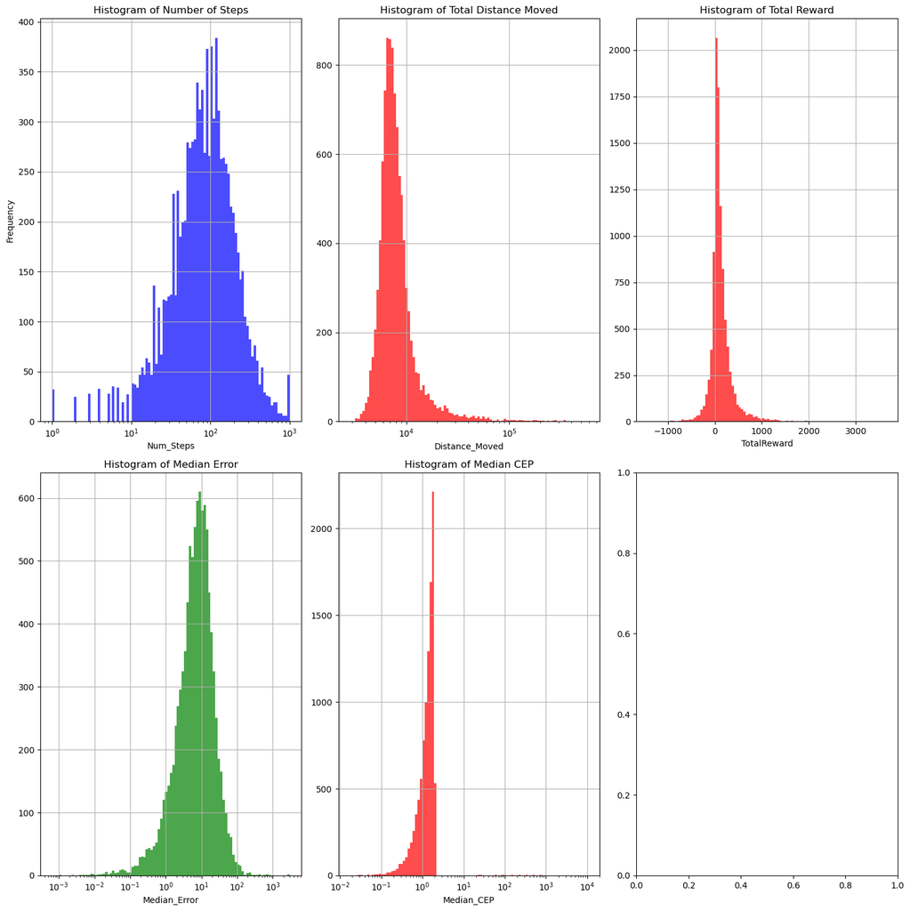

```python
# Create a figure and an array of subplots with 1 row and 3 columns
fig, axes = plt.subplots(2, 3, figsize=(15, 15))
bincount = 100
log_bins = np.logspace(np.log10(results_df['Num_Steps'].min()), np.log10(results_df['Num_Steps'].max()), bincount)


# Plot data
results_df['Num_Steps'].hist(ax=axes[0][0], bins=log_bins, color='blue', alpha=0.7)
axes[0][0].set_title('Histogram of Number of Steps')
axes[0][0].set_xlabel('Num_Steps')
axes[0][0].set_ylabel('Frequency')
axes[0][0].set_xscale('log')

log_bins = np.logspace(np.log10(results_df['Distance_Moved'].min()), np.log10(results_df['Distance_Moved'].max()), bincount)

results_df['Distance_Moved'].hist(ax=axes[0][1], bins=log_bins, color='red', alpha=0.7)
axes[0][1].set_title('Histogram of Total Distance Moved')
axes[0][1].set_xlabel('Distance_Moved')
axes[0][1].set_xscale('log')

results_df['TotalReward'].hist(ax=axes[0][2], bins=bincount, color='red', alpha=0.7)
axes[0][2].set_title('Histogram of Total Reward')
axes[0][2].set_xlabel('TotalReward')

log_bins = np.logspace(np.log10(results_df['Median_Error'].min()), np.log10(results_df['Median_Error'].max()), bincount)


results_df['Median_Error'].hist(ax=axes[1][0], bins=log_bins, color='green', alpha=0.7)
axes[1][0].set_title('Histogram of Median Error')
axes[1][0].set_xlabel('Median_Error')
axes[1][0].set_xscale('log')

log_bins = np.logspace(np.log10(results_df['Median_CEP'].min()), np.log10(results_df['Median_CEP'].max()), bincount)

results_df['Median_CEP'].hist(ax=axes[1][1], bins=log_bins, color='red', alpha=0.7)
axes[1][1].set_title('Histogram of Median CEP')
axes[1][1].set_xlabel('Median_CEP')
axes[1][1].set_xscale('log')


# Adjust layout to prevent overlap
plt.tight_layout()

# Show the plot
plt.show()
```

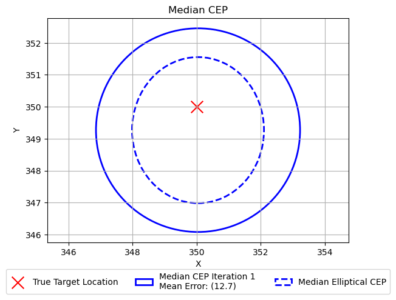

```python
mean_num_steps = results_df['Num_Steps'].mean()
mean_median_error = results_df['Median_Error'].mean()
mean_median_cep = results_df['Median_CEP'].mean()
mean_median_x = results_df['Median_X'].mean()
mean_median_y = results_df['Median_Y'].mean()
mean_mad_x = results_df['MAD_X'].mean()
mean_mad_y = results_df['MAD_Y'].mean()
mean_mean_x = results_df['Mean_X'].mean()
mean_mean_y = results_df['Mean_Y'].mean()
mean_std_x = results_df['Std_X'].mean()
mean_std_y = results_df['Std_Y'].mean()

# Plot Results
plt.scatter(env.target_location[0][0],env.target_location[0][1],color='red', label='True Target Location', marker='x',s=200)

# Plot circle using MAD deviations of x & y values
radius = mean_median_cep
median_cep_legend1 = f'Median CEP Iteration 1 \nMean Error: ({np.round(mean_median_error,1)})'
circle_median = Ellipse((mean_median_x, mean_median_y), 2*radius, 2*radius, edgecolor='blue', facecolor='none', linestyle='-', linewidth=2, label=median_cep_legend1)
plt.gca().add_patch(circle_median)

# Plot ellipse using median absolute distance values
median_cep_legend = f'Median Elliptical CEP'# ({np.round(mean_mad_x, 2)}, {np.round(mean_mad_y, 2)})'
ellipse_median = Ellipse((mean_median_x, mean_median_y), 2*mean_mad_x, 2*mean_mad_y, edgecolor='blue', facecolor='none', linestyle='--', linewidth=2, label=median_cep_legend)
plt.gca().add_patch(ellipse_median)

# Plot circle using std deviations of x & y values
radius = np.sqrt(mean_std_x**2 + mean_std_y**2)
mean_cep_legend = f'$\mu$ CEP ({np.round(radius,2)})'
circle_mean = Ellipse((mean_mean_x, mean_mean_y), 2*radius, 2*radius, edgecolor='green', facecolor='none', linestyle='-', linewidth=2, label=mean_cep_legend)
#plt.gca().add_patch(circle_mean)

# Plot ellipse using standard deviations
std_cep_legend = f'$\sigma$ Elliptical CEP ({np.round(mean_std_x, 2)}, {np.round(mean_std_y, 2)})'
ellipse_std = Ellipse((mean_mean_x, mean_mean_y), 2*mean_std_x, 2*mean_std_y, edgecolor='green', facecolor='none', linestyle='--', linewidth=2, label=std_cep_legend)
#plt.gca().add_patch(ellipse_std)

plt.xlabel('X')
plt.ylabel('Y')
plt.title('Median CEP')
plt.legend(
    loc='lower center',
    bbox_to_anchor=(0.5, -.25),
    ncol=3,
)
plt.grid(True)
plt.axis('equal')  # Equal aspect ratio
plt.show()
```

## Iteration 2:

*Iteration 2*

*Success Metric*

The success of each iteration is measured by the decreasing radius of the error ellipse and the reduction in the Euclidean distance between the center of this ellipse and the true target position. The system iterates until it reaches a predefined number of steps, a time limit, or the emitter is within a specified radius, indicating successful localization. We keep this metric the same across all iterations in order to maintain a fair comparison of success.

Additionally, the system's robustness and accuracy will be tested through Monte Carlo simulations with a series of initial positions to validate the localization estimates against the true target location. Each iteration will be conducted in 2 dimensional environments, where mostly zero-mean Gaussian-distributed error is added to the TOA, $\epsilon_t$ with $\sigma^2 = 10 ns$, to the individual sensor positions, with $\epsilon_x, \epsilon_y, \epsilon_z$ having $\sigma^2 = 2 cm$, including additional time delay due to multipath, with $\epsilon_n$ as $\sigma^2 = 10 ns$, and including a corresponding RSS noise value for multipath & signal fading, $\epsilon_p$ as $\mu = 3 dB$ and $\sigma^2 = 5 dB$.

```python
class DroneEnv(AECEnv):
    def __init__(self, num_drones):
        super().__init__()
        self.width = 2000
        self.height = self.width
        self.max_steps = 1000
        self.current_step = 0
        self.LOCASoln = []
        self.totaldistmoved = 0

        self.movements = np.array([[-5,5], [0,5], [5,5], [-5,0], [0,0], [5,0], [-5,-5], [0,-5], [5,-5]])
        #self.drone_status = [['active'] for _ in range(num_drones)]

        # Currently setting this to fixed value to compare approaches
        self.targ_loc2 = np.array([[350,  350]])
        self.target_location = self.targ_loc2.copy()

        # Uncomment this line if we want to vary target from run-to-run
        #self.target_location = np.random.randint(50, self.width, size=(1, 2))

        # Currently setting this to fixed value to compare approaches
        self.num_drones = num_drones

        #trial run with fixed positions.
        #self.initial_drones_location2 = np.array(([[700, 100], [271, 478],[300,  75],[650, 650], [191, 701], [ 96, 195]]))
        self.initial_drones_location = np.random.randint(50, self.width, size=(self.num_drones, 2))

        self.drones_location =  self.initial_drones_location.copy()

        self.initial_loc = self.initial_drones_location.copy()

        self.target_power = 10

        power_init = -1 * 20 * np.log10((4 * np.pi * 2*self.width * 5e9) / 3e8) +  self.target_power
        self.signal_strength = np.zeros(self.num_drones) + power_init
        self.drone_trajectory = [[] for _ in range(num_drones)]  # List to store trajectories for each drone

        self.metadata = {'render.modes': ['human']}

        self.action_space = Discrete(len(self.movements))  # Discrete action space
        #self.action_space = Discrete(9)  # Discrete action space

        self.observation_space = Box(low=0, high=self.width, shape=(5,), dtype=np.float32)


        # Initialize Q-tables for each agent
        self.q_tables = [np.zeros((self.observation_space.shape[0], self.action_space.n)) for _ in range(num_drones)]

        self.alpha = 0.1  # Learning rate
        self.gamma = 0.9  # Discount factor
        self.epsilon = 0.1  # Epsilon for epsilon-greedy action selection

        self.loca_soln_avg =  np.random.randint(50, self.width, size=(1, 2))

        initial_distances = np.linalg.norm(self.target_location - self.initial_loc, axis=1)
        toas = initial_distances/(3e8) # Convert Distance to Time

        drones_location_err = np.zeros((self.num_drones,2))

        # Calculate LOCA Estimate
        for i in range(self.num_drones): # Add errors
            drones_location_err[i], toas[i] = add_errs(self.initial_loc[i],toas[i])

        LOCASoln = LOCAfun_allcombs_2D(drones_location_err, toas)
        std_x, std_y, mean_x, mean_y, median_x, median_y, mad_x, mad_y = calculate_elliptical_CEP(LOCASoln)
        self.localization_est = np.array([[median_x,median_y]])
        self.loca_err =  np.linalg.norm(self.localization_est - self.target_location, axis=1)
        self.dist_est_after =  np.linalg.norm(self.localization_est - drones_location_err, axis=1)
        self.LOCASoln = LOCASoln.copy()
        cep_radius = np.sqrt(mad_x**2 + mad_y**2)
        self.cep_radius_after = cep_radius.copy()
        self.old_locs = drones_location_err

        self.centroids = []


    def observe(self, agent):
        return self.signal_strength[agent]

    def step(self, action):
        #if DEBUG: print(action)
        self.current_step += 1

        cp_prev = np.round(self.cep_radius_after,2)

        min_cep = 2
        ds = np.abs(np.round(((cp_prev-min_cep)/min_cep),2))

        self.movements = np.array([[0, ds], [0, -1*ds], [ds, 0], [-1*ds, 0], [0, 0], [ds,ds], [ds,-1*ds], [-1*ds,-1*ds], [-1*ds,-1*ds]])

        drones_location_err = np.zeros((self.num_drones,2))
        toas = np.zeros(self.num_drones)

        distances_before_action = np.linalg.norm(self.target_location - self.drones_location, axis=1)
        toas = distances_before_action/(3e8) # Convert Distance to Time

        # Calculate LOCA Estimate
        for i in range(self.num_drones):
            drones_location_err[i], toas[i] = add_errs(self.drones_location[i],toas[i])

        LOCASoln = LOCAfun_allcombs_2D(drones_location_err, toas)
        std_x, std_y, mean_x, mean_y, median_x, median_y, mad_x, mad_y = calculate_elliptical_CEP(LOCASoln)
        localization_est_before = np.array([median_x,median_y])
        loca_err =  np.linalg.norm(localization_est_before - self.target_location, axis=1)
        dist_est_before =  np.linalg.norm(localization_est_before - drones_location_err, axis=1)
        #old_locs = drones_location_err
        #print(old_locs)

        # Calculate Power Before
        power_before = np.zeros(self.num_drones)  # Initialize power_before array
        for i in range(self.num_drones):
            distance = np.linalg.norm(self.target_location - self.drones_location[i])
            if distance == 0:
                received_power = self.target_power
            else:
                received_power = -1 * 20 * np.log10((4 * np.pi * distance * 5e9) / 3e8) + self.target_power

            # value for random error in received power to account for multipath & fading
            rss_err = abs(np.random.normal(loc=mean_rss_err, scale = stdev_rss_err))
            self.signal_strength[i] = received_power - rss_err
            power_before[i] = received_power  # Store received power in the array

        for i, act in enumerate(action):
            movement = self.movements[act]
            self.drones_location[i] =  self.drones_location[i] + movement
            self.drone_trajectory[i].append(self.drones_location[i].copy())#


        distances_after_action = np.linalg.norm(self.target_location - self.drones_location, axis=1)
        toas = distances_after_action/(3e8) # Convert Distance to Time

        # Calculate LOCA Estimate After Action
        for i in range(self.num_drones):
            drones_location_err[i], toas[i] = add_errs(self.drones_location[i],toas[i])

        self.LOCASoln = LOCAfun_allcombs_2D(drones_location_err, toas) #locasoln_after
        std_x, std_y, mean_x, mean_y, median_x, median_y, mad_x, mad_y = calculate_elliptical_CEP(self.LOCASoln)

        #print(drones_location_err)
        #print(drones_location_err-old_locs)
        #cep_radius_after = np.sqrt(std_x**2 + std_y**2)
        cep_radius_after = np.sqrt(mad_x**2 + mad_y**2)

        self.totaldistmoved = np.sum(np.sqrt(np.sum((drones_location_err-self.old_locs)**2, axis=1)))

        #if self.totaldistmoved > 1:
        #    print(self.totaldistmoved)

        self.localization_est_after = np.array([median_x,median_y])
        self.loca_err =  np.linalg.norm(self.localization_est_after - self.target_location, axis=1)
        self.centroids.append(self.localization_est_after.copy())

        dist_est_after =  np.linalg.norm(self.localization_est_after - drones_location_err, axis=1)


        #print(dist_est_after)

        # Caclulate Power After Action
        power_after = np.zeros(self.num_drones)  # Initialize power_after array
        for i in range(self.num_drones):
            distance = np.linalg.norm(self.target_location - self.drones_location[i])
            if distance == 0:
                received_power = self.target_power
            else:
                received_power = -1 * 20 * np.log10((4 * np.pi * distance * 5e9) / 3e8) + self.target_power

            # value for random error in received power to account for multipath & fading
            rss_err = abs(np.random.normal(loc=mean_rss_err, scale = stdev_rss_err))

            self.signal_strength[i] =  received_power - rss_err
            power_after[i] = received_power  # Store received power in the array

        # Rewards

        rewards = np.where(dist_est_after < dist_est_before, 1, -1)

        # Check for termination conditions

        # Assign a threshold for max power: Assume 60 meters from 10dBm emitter
        target_power_threshold = -1 * 20 * np.log10((4 * np.pi * 60 * 5e9) / 3e8) + self.target_power

        done_max_steps = self.current_step >= self.max_steps
        done_target_CEP = cep_radius_after <= min_cep
        done = done_max_steps or done_target_CEP
        if done:
           # if DEBUG: print('Final LOCA Target Estimate: ', np.round(localization_est_after,2))
           # if DEBUG: print('Final LOCA Error (m): ', np.round(loca_err,2))
            self.LOCASoln = LOCAfun_allcombs_2D(drones_location_err, toas)

        return self.drones_location, rewards, done, self.LOCASoln, {}

    def reset(self):
        self.initial_loc =  np.random.randint(50, self.width, size=(self.num_drones, 2))
        self.drones_location = self.initial_loc.copy()#np.random.randint(0, self.width, size=(self.num_drones, 2))
        self.signal_strength = np.zeros(self.num_drones) - 200
        self.current_step = 0
        power_init = -1 * 20 * np.log10((4 * np.pi * 2*self.width * 5e9) / 3e8) +  self.target_power
        self.signal_strength = np.zeros(self.num_drones) + power_init
        self.q_tables = [np.zeros((self.observation_space.shape[0], self.action_space.n)) for _ in range(num_drones)]

        self.loca_soln_avg =  np.random.randint(50, self.width, size=(1, 2))
        initial_distances = np.linalg.norm(self.target_location - self.initial_loc, axis=1)
        toas = initial_distances/(3e8) # Convert Distance to Time
        self.drones_location_err = np.zeros((self.num_drones,2))

        # Calculate LOCA Estimate
        for i in range(self.num_drones): # Add errors
            self.drones_location_err[i], toas[i] = add_errs(self.initial_loc[i],toas[i])

        LOCASoln = LOCAfun_allcombs_2D(self.drones_location_err, toas)
        std_x, std_y, mean_x, mean_y, median_x, median_y, mad_x, mad_y = calculate_elliptical_CEP(LOCASoln)

        #cep_radius = np.sqrt(std_x**2 + std_y**2)
        cep_radius = np.sqrt(mad_x**2 + mad_y**2)
       #print("Initial CEP Radius", np.round(cep_radius))
        self.localization_est = np.array([[median_x,median_y]])
        self.loca_err =  np.linalg.norm(self.localization_est - self.target_location, axis=1)
        self.LOCASoln = LOCASoln.copy()
        self.cep_radius_after = cep_radius.copy()


        for i in range(self.num_drones):
            self.drone_trajectory[i] = [np.copy(self.drones_location[i])]  # Reset drone trajectory
        return self.signal_strength

    def render(self, mode='human'):
        pass

    def update_q_table(self, agent, state, action, reward, next_state):
        old_q_value = self.q_tables[agent][state, action]
        next_max_q_value = np.max(self.q_tables[agent][next_state])
        new_q_value = old_q_value + self.alpha * (reward + self.gamma * next_max_q_value - old_q_value)
        self.q_tables[agent][state, action] = new_q_value

    def choose_action(self, agent, state):
        if np.random.rand() < self.epsilon:
            #if DEBUG: print("Exploration")
            #action_out = np.random.randint(self.action_space.n) % 9
            action_out = np.random.randint(self.action_space.n) % len(self.movements)
            return  action_out # Exploration
        else:
            #if DEBUG: print("Exploitation")
            #action_out = np.argmax(self.q_tables[agent][state]) % 9
            action_out = np.argmax(self.q_tables[agent][state]) % len(self.movements)
            return action_out  # Exploitation

    def convert_state_to_int(self, state):
        # Use modulo operation to ensure the state representation falls within the valid range
        npsst = np.sum(state)
        if npsst > 10000: npsst = 10000
        elif npsst < -10000: npsst = -10000
        else: npsst = npsst
        return int(npsst) % self.observation_space.shape[0]
```

```python
import time
start_time = time.time()

# Number of drones (agents)
num_drones = 6
env = DroneEnv(num_drones)
num_simulations = 1
DEBUG=False

ls_numsteps =[]
ls_median_cep =[]
ls_median_err=[]

ls_stddev_x =[]
ls_stddev_y =[]
ls_mean_x=[]
ls_mean_y=[]
ls_med_x=[]
ls_med_y=[]
ls_mad_x=[]
ls_mad_y=[]
ls_totaldistmoved = []
total_rewards_per_simulation = []



for i in range(num_simulations):
    obs = env.reset()
    initial_drones_location = env.drones_location  # Initial drone positions
    total_reward = 0

    if DEBUG: print('Initial LOCA Target Estimate: ', np.round(env.localization_est,2))
    if DEBUG: print('Initial LOCA Error (m): ', np.round(env.loca_err,2))
    initial_LOCA = env.LOCASoln
    initial_distances = np.linalg.norm(env.target_location - env.initial_loc, axis=1)

    for _ in range(1000):
        actions = [env.choose_action(agent, env.convert_state_to_int(env.drones_location[agent])) for agent in range(num_drones)]
        next_obs, rewards, done, LOCASoln, _ = env.step(actions)

        total_reward += np.sum(rewards)

        for agent in range(num_drones):
            state = int(env.convert_state_to_int(env.drones_location[agent]))
            if DEBUG: print(f"Agent {agent + 1} state: {state}")  # Add this line to print the state
            action = actions[agent]
            next_state = env.convert_state_to_int(next_obs[agent])
            #print(f"Agent {agent + 1} state: {next_state}")  # Add this line to print the state
            reward = rewards[agent]
            env.update_q_table(agent, state, action, reward, next_state)
        obs = next_obs
        if done:
            final_drones_location = env.drones_location
            final_distances = np.linalg.norm(env.target_location - env.drones_location, axis=1)
            final_loc = np.average(env.LOCASoln, axis = 0)

            loca_err =  np.linalg.norm(final_loc - env.target_location, axis = 1)
            estimated_positions = np.array(env.LOCASoln)
            break
    std_x, std_y, mean_x, mean_y, median_x, median_y, mad_x, mad_y = calculate_elliptical_CEP(estimated_positions)
    med_err =  np.linalg.norm(np.array(median_x,median_y)-env.target_location,axis = 1)
    if DEBUG: print("Standard Deviation (x,y):",  np.round(std_x,2),", ",np.round(std_y,2))
    if DEBUG: print("Median Absolute Distance  (x,y):", np.round(mad_x, 2),", ",np.round(mad_y,2))
    if DEBUG: print("Mean Target Estimate (x,y):", np.round(mean_x,2),", ",np.round(mean_y,2))
    if DEBUG: print("Median Target Estimate (x,y):", np.round(median_x, 2),", ",np.round(median_y,2))
    if DEBUG: print("Median Error:", np.round(med_err,2))

    if DEBUG: print('Final LOCA Target Estimate: ', np.round(final_loc,2))
    if DEBUG: print('Final LOCA Error (m): ', np.round(loca_err,2))

    if DEBUG: print("Initial Drone-to-Target Distances\n",np.round(initial_distances,2))
    if DEBUG: print("Final Drone-to-Target Distances\n",np.round(final_distances,2))
    if DEBUG: plot_locations(env.initial_loc, final_drones_location, env.target_location, env.current_step)

    if DEBUG: received_power_initial = -1 * 20 * np.log10((4 * np.pi * initial_distances * 5e9) / 3e8) + env.target_power
    if DEBUG: print("Initial Power",np.round(received_power_initial,2))
    if DEBUG: received_power_final = -1 * 20 * np.log10((4 * np.pi * final_distances * 5e9) / 3e8) + env.target_power
    if DEBUG: print("Final Power",np.round(received_power_final,2))
    if DEBUG: print("Power Improvement",np.round(received_power_final-received_power_initial,2))
    if DEBUG: print("Completion Steps: ", env.current_step)

    #save off values
    ls_numsteps.append(env.current_step)
    ls_median_err.append(med_err[-1])
    ls_median_cep.append(np.sqrt(mad_x**2 + mad_y**2))
    ls_totaldistmoved.append(env.totaldistmoved)
    total_rewards_per_simulation.append(total_reward)


    # Optional:
    ls_stddev_x.append(np.round(std_x, 2))
    ls_stddev_y.append(np.round(std_y, 2))
    ls_med_x.append(np.round(median_x, 2))
    ls_med_y.append(np.round(median_y, 2))
    ls_mean_x.append(np.round(mean_x, 2))
    ls_mean_y.append(np.round(mean_y, 2))
    ls_mad_x.append(np.round(mad_x, 2))
    ls_mad_y.append(np.round(mad_y, 2))


    # Print progress every 25 steps
    if i % 100 == 1:
        current_time = time.time()
        elapsed_time = current_time - start_time
        avg_time_per_step = elapsed_time / i
        estimated_total_time = avg_time_per_step * num_simulations
        estimated_time_remaining = estimated_total_time - elapsed_time

        print(f"Step {i}/{num_simulations}")
        print(f"Time elapsed: {elapsed_time:.2f} seconds")
        print(f"Estimated time to complete: {estimated_time_remaining:.2f} seconds")

    if i == num_simulations:
        print("Done")


#print("Number of Steps: ", ls_numsteps)
#print("Median Error: ", np.round(ls_median_err,2))
#print("Median CEP: ", np.round(ls_median_cep,2))

# print(ls_stddev_x)
# print(ls_stddev_y)
# print(ls_mean_x)
# print(ls_mean_y)
# print(ls_med_x)
# print(ls_med_y)
# print(ls_mad_x)
# print(ls_mad_y)
```

```
Initial Drone-to-Target Distances
 [[ 337  394]
 [1789  851]
 [ 541 1781]
 [1709 1309]
 [ 681  761]
 [1540  980]]
Final Drone Locations
 [[1026  376]
 [3169 1326]
 [ -19  516]
 [1209 1164]
 [1713  544]
 [1747   62]]
```

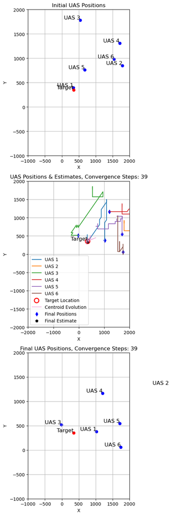

```python
print("Initial Drone-to-Target Distances\n",np.round(env.initial_loc,2))
print("Final Drone Locations\n", env.drones_location)
plot_locations(env.initial_loc, env.drones_location, env.target_location, env.current_step)
```

```python
import pandas as pd

results_df = pd.DataFrame({'Num_Steps': ls_numsteps, 'Median_Error': ls_median_err, 'Median_CEP': ls_median_cep,
                           'Median_X': ls_med_x, 'Median_Y': ls_med_y, 'MAD_X': ls_mad_x, 'MAD_Y': ls_mad_y,
                          'Mean_X': ls_mean_x, 'Mean_Y': ls_mean_y, 'Std_X': ls_stddev_x, 'Std_Y': ls_stddev_y,
                          'Distance_Moved': ls_totaldistmoved, 'TotalReward': total_rewards_per_simulation} )

results_df.to_csv('iter2_results1.csv', index=False)
results_df = pd.read_csv('iter2_results10000_fin.csv')

results_df.describe().style.format("{:.2f}")
```

|  | Num_Steps | Median_Error | Median_CEP | Median_X | Median_Y | MAD_X | MAD_Y | Mean_X | Mean_Y | Std_X | Std_Y | Distance_Moved | TotalReward |
| --- | --- | --- | --- | --- | --- | --- | --- | --- | --- | --- | --- | --- | --- |
| count | 10000.00 | 10000.00 | 10000.00 | 10000.00 | 10000.00 | 10000.00 | 10000.00 | 10000.00 | 10000.00 | 10000.00 | 10000.00 | 10000.00 | 10000.00 |
| mean | 165.41 | 17.66 | 6.50 | 350.79 | 349.51 | 4.19 | 4.36 | 338.96 | 346.14 | 188.77 | 111.79 | 12100.01 | -1.56 |
| std | 192.49 | 63.29 | 78.99 | 46.46 | 57.77 | 54.81 | 56.93 | 2334.86 | 910.41 | 8301.87 | 2998.90 | 22363.50 | 104.12 |
| min | 1.00 | 0.00 | 0.02 | -1171.48 | -2950.14 | 0.01 | 0.01 | -199466.76 | -73245.21 | 0.04 | 0.05 | 2885.16 | -1300.00 |
| 25% | 54.00 | 4.03 | 0.99 | 343.70 | 343.48 | 0.56 | 0.55 | 343.17 | 342.86 | 2.66 | 2.47 | 6304.95 | -26.00 |
| 50% | 102.00 | 9.10 | 1.41 | 349.98 | 350.15 | 0.89 | 0.88 | 350.02 | 350.02 | 5.45 | 5.08 | 7661.82 | 14.00 |
| 75% | 194.00 | 17.97 | 1.74 | 356.59 | 356.77 | 1.24 | 1.24 | 357.35 | 357.57 | 13.76 | 12.58 | 10663.44 | 52.00 |
| max | 1000.00 | 3993.79 | 4381.00 | 3174.04 | 2776.50 | 3664.58 | 2582.46 | 116816.90 | 39598.88 | 739780.28 | 216649.97 | 879449.49 | 494.00 |

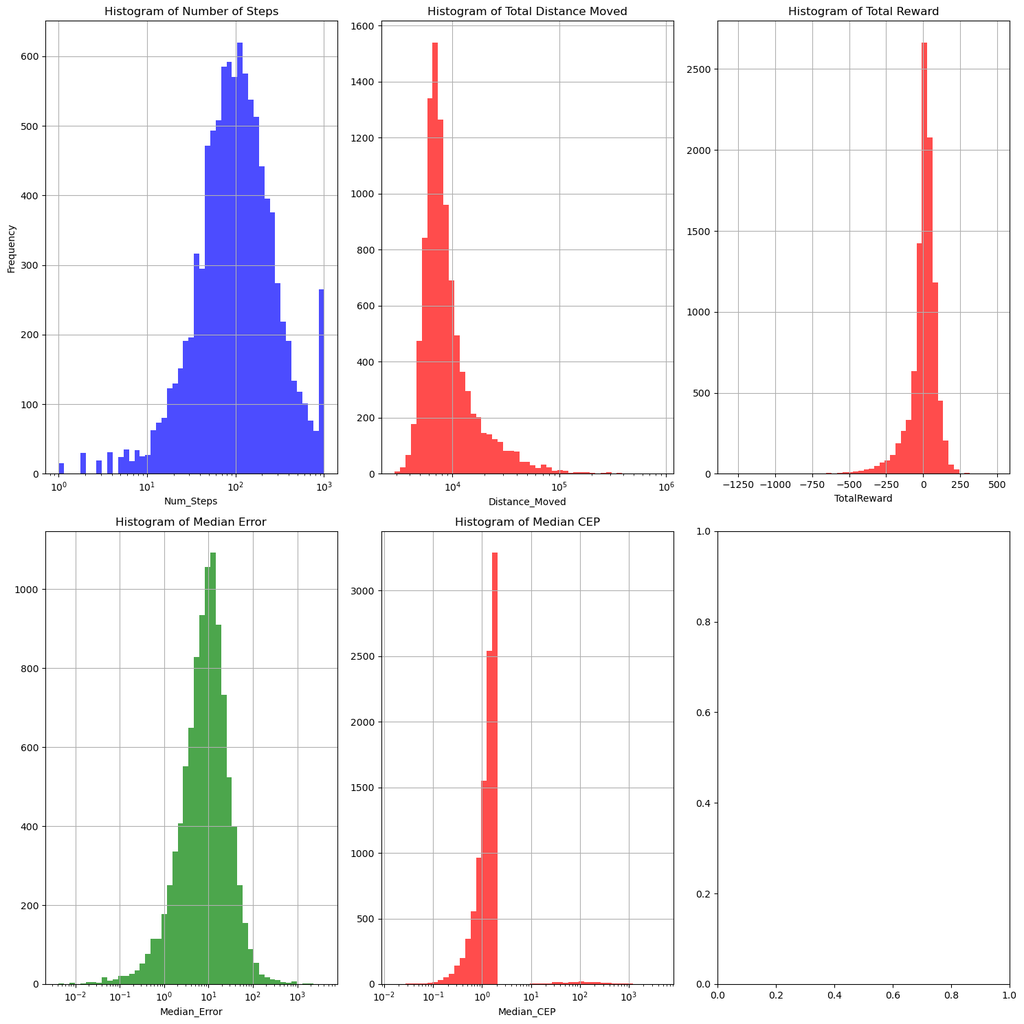

```python
# Create a figure and an array of subplots with 1 row and 3 columns
fig, axes = plt.subplots(2, 3, figsize=(15, 15))
bincount = 50
log_bins = np.logspace(np.log10(results_df['Num_Steps'].min()), np.log10(results_df['Num_Steps'].max()), bincount)


# Plot data
results_df['Num_Steps'].hist(ax=axes[0][0], bins=log_bins, color='blue', alpha=0.7)
axes[0][0].set_title('Histogram of Number of Steps')
axes[0][0].set_xlabel('Num_Steps')
axes[0][0].set_ylabel('Frequency')
axes[0][0].set_xscale('log')

log_bins = np.logspace(np.log10(results_df['Distance_Moved'].min()), np.log10(results_df['Distance_Moved'].max()), bincount)

results_df['Distance_Moved'].hist(ax=axes[0][1], bins=log_bins, color='red', alpha=0.7)
axes[0][1].set_title('Histogram of Total Distance Moved')
axes[0][1].set_xlabel('Distance_Moved')
axes[0][1].set_xscale('log')


results_df['TotalReward'].hist(ax=axes[0][2], bins=bincount, color='red', alpha=0.7)
axes[0][2].set_title('Histogram of Total Reward')
axes[0][2].set_xlabel('TotalReward')

log_bins = np.logspace(np.log10(results_df['Median_Error'].min()), np.log10(results_df['Median_Error'].max()), bincount)


results_df['Median_Error'].hist(ax=axes[1][0], bins=log_bins, color='green', alpha=0.7)
axes[1][0].set_title('Histogram of Median Error')
axes[1][0].set_xlabel('Median_Error')
axes[1][0].set_xscale('log')

log_bins = np.logspace(np.log10(results_df['Median_CEP'].min()), np.log10(results_df['Median_CEP'].max()), bincount)

results_df['Median_CEP'].hist(ax=axes[1][1], bins=log_bins, color='red', alpha=0.7)
axes[1][1].set_title('Histogram of Median CEP')
axes[1][1].set_xlabel('Median_CEP')
axes[1][1].set_xscale('log')


# Adjust layout to prevent overlap
plt.tight_layout()

# Show the plot
plt.show()
```

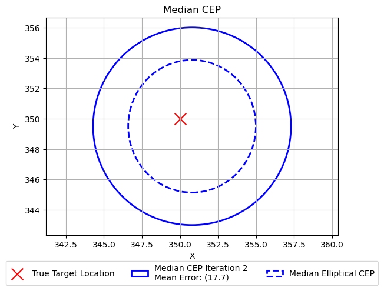

```python
mean_num_steps = results_df['Num_Steps'].mean()
mean_median_error = results_df['Median_Error'].mean()
mean_median_cep = results_df['Median_CEP'].mean()
mean_median_x = results_df['Median_X'].mean()
mean_median_y = results_df['Median_Y'].mean()
mean_mad_x = results_df['MAD_X'].mean()
mean_mad_y = results_df['MAD_Y'].mean()
mean_mean_x = results_df['Mean_X'].mean()
mean_mean_y = results_df['Mean_Y'].mean()
mean_std_x = results_df['Std_X'].mean()
mean_std_y = results_df['Std_Y'].mean()

# Plot Results
plt.scatter(env.target_location[0][0],env.target_location[0][1],color='red', label='True Target Location', marker='x',s=200)

# Plot circle using MAD deviations of x & y values
radius = mean_median_cep
median_cep_legend2 = f'Median CEP Iteration 2 \nMean Error: ({np.round(mean_median_error,1)})'
circle_median = Ellipse((mean_median_x, mean_median_y), 2*radius, 2*radius, edgecolor='blue', facecolor='none', linestyle='-', linewidth=2, label=median_cep_legend2)
plt.gca().add_patch(circle_median)

# Plot ellipse using median absolute distance values
median_cep_legend = f'Median Elliptical CEP'# ({np.round(mean_mad_x, 2)}, {np.round(mean_mad_y, 2)})'
ellipse_median = Ellipse((mean_median_x, mean_median_y), 2*mean_mad_x, 2*mean_mad_y, edgecolor='blue', facecolor='none', linestyle='--', linewidth=2, label=median_cep_legend)
plt.gca().add_patch(ellipse_median)

# Plot circle using std deviations of x & y values
radius = np.sqrt(mean_std_x**2 + mean_std_y**2)
mean_cep_legend = f'$\mu$ CEP ({np.round(radius,2)})'
circle_mean = Ellipse((mean_mean_x, mean_mean_y), 2*radius, 2*radius, edgecolor='green', facecolor='none', linestyle='-', linewidth=2, label=mean_cep_legend)
#plt.gca().add_patch(circle_mean)

# Plot ellipse using standard deviations
std_cep_legend = f'$\sigma$ Elliptical CEP ({np.round(mean_std_x, 2)}, {np.round(mean_std_y, 2)})'
ellipse_std = Ellipse((mean_mean_x, mean_mean_y), 2*mean_std_x, 2*mean_std_y, edgecolor='green', facecolor='none', linestyle='--', linewidth=2, label=std_cep_legend)
#plt.gca().add_patch(ellipse_std)

plt.xlabel('X')
plt.ylabel('Y')
plt.title('Median CEP')
plt.legend(
    loc='lower center',
    bbox_to_anchor=(0.5, -.25),
    ncol=3,
)
plt.grid(True)
plt.axis('equal')  # Equal aspect ratio
plt.show()
```

## Iteration 3:

*Iteration 3*

*Success Metric*

The success of each iteration is measured by the decreasing radius of the error ellipse and the reduction in the Euclidean distance between the center of this ellipse and the true target position. The system iterates until it reaches a predefined number of steps, a time limit, or the emitter is within a specified radius, indicating successful localization. We keep this metric the same across all iterations in order to maintain a fair comparison of success.

Additionally, the system's robustness and accuracy will be tested through Monte Carlo simulations with a series of initial positions to validate the localization estimates against the true target location. Each iteration will be conducted in 2 dimensional environments, where mostly zero-mean Gaussian-distributed error is added to the TOA, $\epsilon_t$ with $\sigma^2 = 10 ns$, to the individual sensor positions, with $\epsilon_x, \epsilon_y, \epsilon_z$ having $\sigma^2 = 2 cm$, including additional time delay due to multipath, with $\epsilon_n$ as $\sigma^2 = 10 ns$, and including a corresponding RSS noise value for multipath & signal fading, $\epsilon_p$ as $\mu = 3 dB$ and $\sigma^2 = 5 dB$.

```python
from itertools import combinations
import numpy as np

def generate_combinations(numsens):
    combels_all = []
    for pqty in range(5, numsens + 1):
        for pmax in range(5, numsens + 1):
            for comb in combinations(range(1, pmax + 1), pqty):
                pad = [0] * (numsens - len(comb))
                combels_all.append(list(comb) + pad)
    return np.array(combels_all)

def calculate_drone_contributions(combels_all, distances, num2move, nsens):
    # Create a result matrix
    result_matrix = np.zeros((len(distances), nsens))

    # Assign distances to the relevant drone indices
    for idx, row in enumerate(combels_all):
        filtered_indices = [i - 1 for i in row if i > 0]  # Adjust for zero-based indexing
        result_matrix[idx, filtered_indices] = distances[idx]

    # Sum up the results by drone
    summed_results = np.sum(result_matrix, axis=0)
    worst_indices = np.argsort(summed_results)[-num2move:]  # Get indices for the highest values
    return worst_indices
```

```python
class DroneEnv(AECEnv):
    def __init__(self, num_drones):
        super().__init__()
        self.width = 2000
        self.height = self.width
        self.max_steps = 1000
        self.current_step = 0
        self.LOCASoln = []
        self.cep_radius_after = []

        # Currently setting this to fixed value to compare approaches
        self.targ_loc2 = np.array([[350,  350]])
        self.target_location = self.targ_loc2.copy()

        # Uncomment this line if we want to vary target from run-to-run
        #self.target_location = np.random.randint(50, self.width, size=(1, 2))

        # Currently setting this to fixed value to compare approaches
        self.num_drones = num_drones
        #self.initial_drones_location2 = np.array(([[483, 259], [271, 478],[238,  75],[469, 157], [191, 201], [ 96, 195]]))
        self.initial_drones_location2 = np.array(([[700, 100], [271, 478],[300,  75],[650, 650], [191, 701], [ 96, 195]]))
        self.initial_drones_location2 = np.random.randint(50, self.width, size=(self.num_drones, 2))

        # or use
        if np.size(self.initial_drones_location2,0) < self.num_drones:
            self.initial_drones_location2 = np.random.randint(50, self.width, size=(self.num_drones, 2))

        self.drones_location =  self.initial_drones_location2.copy()

        self.initial_loc = self.initial_drones_location2.copy()
        # Uncomment this line if we want to vary initial locations from run-to-run
        #self.initial_loc = self.drones_location.copy()

        self.target_power = 10
        #print("Drones",self.drones_location)

        power_init = -1 * 20 * np.log10((4 * np.pi * 2*self.width * 5e9) / 3e8) +  self.target_power
        self.signal_strength = np.zeros(self.num_drones) + power_init
        self.drone_trajectory = [[] for _ in range(num_drones)]  # List to store trajectories for each drone
        self.centroids = []

        self.metadata = {'render.modes': ['human']}

        self.action_space = Discrete(9)  # Discrete action space
        #self.observation_space = Box(low=0, high=self.width, shape=(5,), dtype=np.float32)
        self.observation_space = Box(low=0, high=self.width, shape=(num_drones,), dtype=np.float32)

        # Initialize Q-tables for each agent
        self.q_tables = [np.zeros((self.observation_space.shape[0], self.action_space.n)) for _ in range(num_drones)]

        self.alpha = 0.1  # Learning rate
        self.gamma = 0.9  # Discount factor
        self.epsilon = 0.1  # Epsilon for epsilon-greedy action selection

        self.loca_soln_avg =  np.random.randint(50, self.width, size=(1, 2))

        initial_distances = np.linalg.norm(self.target_location - self.initial_loc, axis=1)
        toas = initial_distances/(3e8) # Convert Distance to Time

        drones_location_err = np.zeros((self.num_drones,2))

        # Calculate LOCA Estimate
        for i in range(self.num_drones): # Add errors
            drones_location_err[i], toas[i] = add_errs(self.initial_loc[i],toas[i])

        LOCASoln = LOCAfun_allcombs_2D(drones_location_err, toas)
        std_x, std_y, mean_x, mean_y, median_x, median_y, mad_x, mad_y = calculate_elliptical_CEP(LOCASoln)

        #cep_radius = np.sqrt(std_x**2 + std_y**2)
        cep_radius = np.sqrt(mad_x**2 + mad_y**2)
        print("Initial CEP Radius", np.round(cep_radius))
        self.localization_est = np.array([[median_x,median_y]])
        self.loca_err =  np.linalg.norm(self.localization_est - self.target_location, axis=1)
        self.LOCASoln = LOCASoln.copy()
        self.cep_radius_after = cep_radius.copy()
        self.old_locs = drones_location_err



    def observe(self, agent):
        return self.signal_strength[agent]


    def step(self, action):
        #print(f"Current Step: {self.current_step}")  # To track steps

        self.current_step += 1
        cp_prev = np.round(self.cep_radius_after,2)

        min_cep = 2
        ds = np.abs(np.round(((cp_prev-min_cep)/min_cep),2))


        movements = np.array([[0, ds], [0, -1*ds], [ds, 0], [-1*ds, 0], [0, 0], [ds,ds], [ds,-1*ds], [-1*ds,-1*ds], [-1*ds,-1*ds]])

        # Update drone positions based on actions and calculate new positions error
        drones_location_err = np.zeros((self.num_drones, 2))
        toas = np.zeros(self.num_drones)

        # Adding penalty for moving out of bounds
        #boundary_violation_penalty = -10 # Starting penalty
        boundary_violation_penalty = -1 # Starting penalty
        #boundary_violation_penalty = 0 # Starting penalty

        # Initialize rewards
        #rewards = np.full(self.num_drones, -1)  # Default to -1
        rewards = np.full(self.num_drones, 1)  # Default to 1

        for i, act in enumerate(action):
            movement = movements[act]

            #self.drones_location[i] += movement
        # Adjustment for out of bounds
            new_position = self.drones_location[i] + movement
            if np.linalg.norm(new_position - self.localization_est) > max_dist:
                rewards[i] += boundary_violation_penalty
                pass # do nothing: reject the move
            else:
                self.drones_location[i] = new_position

            self.drone_trajectory[i].append(self.drones_location[i].copy())
            # Calculate distance and time of arrival for new position
            distance = np.linalg.norm(self.target_location - self.drones_location[i])
            toas[i] = distance / 3e8
            drones_location_err[i], toas[i] = add_errs(self.drones_location[i], toas[i])

        # Recalculate LOCA solution and CEP after movements
        LOCASoln_after = LOCAfun_allcombs_2D(drones_location_err, toas)
        std_x, std_y, mean_x, mean_y, median_x, median_y, mad_x, mad_y = calculate_elliptical_CEP(LOCASoln_after)
        self.localization_est = np.array([median_x, median_y])
        self.centroids.append(self.localization_est.copy())

        self.LOCASoln = LOCASoln_after

        #cep_radius = np.sqrt(std_x**2 + std_y**2)
        cep_radius_after = np.sqrt(mad_x**2 + mad_y**2)
        self.totaldistmoved = np.sum(np.sqrt(np.sum((drones_location_err-self.old_locs)**2, axis=1)))


        # Calculate CEP before movements using the previous LOCA solution
     #   std_x_before, std_y_before, mean_x_before, mean_y_before, median_x_before, median_y_before, mad_x_before, mad_y_before = calculate_elliptical_CEP(self.LOCASoln)
        #cep_radius_before = np.sqrt(std_x**2 + std_y**2)
      #  cep_radius_before = np.sqrt(mad_x**2 + mad_y**2)

        # Generate combels_all dynamically based on the number of drones
        combels_all = generate_combinations(self.num_drones)

        # Calculate distances of LOCASoln to the centroid
        distances = np.linalg.norm(self.LOCASoln - self.localization_est, axis=1)

        # Calculate drone contributions
        num2move = 1  # Number of drones you want to consider for movement
        worst_indices = calculate_drone_contributions(combels_all, distances, num2move, self.num_drones)


        for idx in worst_indices:
            #rewards[idx] = 1  # Reward the drones that are most off
            rewards[idx] = -1  # Discount the drones that are most off


        # Check for termination conditions
        done_max_steps = self.current_step >= self.max_steps
        done_target_CEP = cep_radius_after <= min_cep
        done = done_max_steps or done_target_CEP
        #if done:
           # print("Final CEP radius: ", np.round(cep_radius_after,2))

       # print(f"CEP Radius Before: {cep_radius_before}, After: {cep_radius_after}")  # To track CEP changes
       # print(f"Termination Status: {done}")  # To confirm if 'done' is ever True


        # Update LOCA solution

        return self.drones_location, rewards, done, self.LOCASoln, {}

    def reset(self):
        self.initial_loc =  np.random.randint(50, self.width, size=(self.num_drones, 2))
        self.drones_location = self.initial_loc.copy()#np.random.randint(0, self.width, size=(self.num_drones, 2))
        self.signal_strength = np.zeros(self.num_drones) - 200
        self.current_step = 0
        power_init = -1 * 20 * np.log10((4 * np.pi * 2*self.width * 5e9) / 3e8) +  self.target_power
        self.signal_strength = np.zeros(self.num_drones) + power_init
        self.q_tables = [np.zeros((self.observation_space.shape[0], self.action_space.n)) for _ in range(num_drones)]
        self.loca_soln_avg =  np.random.randint(50, self.width, size=(1, 2))

        initial_distances = np.linalg.norm(self.target_location - self.initial_loc, axis=1)
        toas = initial_distances/(3e8) # Convert Distance to Time

        drones_location_err = np.zeros((self.num_drones,2))

        # Calculate LOCA Estimate
        for i in range(self.num_drones): # Add errors
            drones_location_err[i], toas[i] = add_errs(self.initial_loc[i],toas[i])

        LOCASoln = LOCAfun_allcombs_2D(drones_location_err, toas)
        std_x, std_y, mean_x, mean_y, median_x, median_y, mad_x, mad_y = calculate_elliptical_CEP(LOCASoln)

        #cep_radius = np.sqrt(std_x**2 + std_y**2) / 2
        cep_radius = np.sqrt(mad_x**2 + mad_y**2)
       #print("Initial CEP Radius", np.round(cep_radius))
        self.localization_est = np.array([[median_x,median_y]])
        self.loca_err =  np.linalg.norm(self.localization_est - self.target_location, axis=1)
        self.LOCASoln = LOCASoln.copy()
        self.cep_radius_after = cep_radius.copy()


        for i in range(self.num_drones):
            self.drone_trajectory[i] = [np.copy(self.drones_location[i])]  # Reset drone trajectory
        return self.signal_strength


    def render(self, mode='human'):
        pass

    def update_q_table(self, agent, state, action, reward, next_state):
        old_q_value = self.q_tables[agent][state, action]
        next_max_q_value = np.max(self.q_tables[agent][next_state])
        new_q_value = old_q_value + self.alpha * (reward + self.gamma * next_max_q_value - old_q_value)
        self.q_tables[agent][state, action] = new_q_value

    def choose_action(self, agent, state):
        if np.random.rand() < self.epsilon:
            #print("Exploration")
            action_out = np.random.randint(self.action_space.n) % 9
            return  action_out # Exploration
        else:
            #print("Exploitation")
            action_out = np.argmax(self.q_tables[agent][state]) % 9
            return action_out  # Exploitation

    def convert_state_to_int(self, state):
        # Use modulo operation to ensure the state representation falls within the valid range
        npsst = np.sum(state)
        if npsst > 10000: npsst = 10000
        elif npsst < -10000: npsst = -1000
        else: npsst = npsst
        return int(npsst) % self.observation_space.shape[0]
```

```python
import time
start_time = time.time()

# Number of drones (agents)
num_drones = 6
env = DroneEnv(num_drones)
num_simulations = 1
DEBUG=False

ls_numsteps =[]
ls_median_cep =[]
ls_median_err=[]

ls_stddev_x =[]
ls_stddev_y =[]
ls_mean_x=[]
ls_mean_y=[]
ls_med_x=[]
ls_med_y=[]
ls_mad_x=[]
ls_mad_y=[]
ls_totaldistmoved = []
total_rewards_per_simulation = []
ls_locations = []


for i in range(num_simulations):
    obs = env.reset()
    initial_drones_location = env.drones_location  # Initial drone positions
    total_reward = 0

    if DEBUG: print('Initial LOCA Target Estimate: ', np.round(env.localization_est,2))
    if DEBUG: print('Initial LOCA Error (m): ', np.round(env.loca_err,2))
    initial_LOCA = env.LOCASoln
    initial_distances = np.linalg.norm(env.target_location - env.initial_loc, axis=1)

    for _ in range(1000):
        actions = [env.choose_action(agent, env.convert_state_to_int(env.drones_location[agent])) for agent in range(num_drones)]
        next_obs, rewards, done, LOCASoln, _ = env.step(actions)

        total_reward += np.sum(rewards)

        for agent in range(num_drones):
            state = int(env.convert_state_to_int(env.drones_location[agent]))
            if DEBUG: print(f"Agent {agent + 1} state: {state}")  # Add this line to print the state
            action = actions[agent]
            next_state = env.convert_state_to_int(next_obs[agent])
            reward = rewards[agent]
            env.update_q_table(agent, state, action, reward, next_state)
        obs = next_obs
        if done:
            final_drones_location = env.drones_location
            final_distances = np.linalg.norm(env.target_location - env.drones_location, axis=1)
            final_loc = np.average(env.LOCASoln, axis = 0)

            loca_err =  np.linalg.norm(final_loc - env.target_location, axis = 1)
            estimated_positions = np.array(env.LOCASoln)
            break

    med_err =  np.linalg.norm(np.array(median_x,median_y)-env.target_location,axis = 1)
    if DEBUG: print("Standard Deviation (x,y):",  np.round(std_x,2),", ",np.round(std_y,2))
    if DEBUG: print("Median Absolute Distance  (x,y):", np.round(mad_x, 2),", ",np.round(mad_y,2))
    if DEBUG: print("Mean Target Estimate (x,y):", np.round(mean_x,2),", ",np.round(mean_y,2))
    if DEBUG: print("Median Target Estimate (x,y):", np.round(median_x, 2),", ",np.round(median_y,2))
    if DEBUG: print("Median Error:", np.round(med_err,2))

    if DEBUG: print('Final LOCA Target Estimate: ', np.round(final_loc,2))
    if DEBUG: print('Final LOCA Error (m): ', np.round(loca_err,2))

    if DEBUG: print("Initial Drone-to-Target Distances\n",np.round(initial_distances,2))
    if DEBUG: print("Final Drone-to-Target Distances\n",np.round(final_distances,2))
    if DEBUG: plot_locations(env.initial_loc, final_drones_location, env.target_location, env.current_step)

    if DEBUG: received_power_initial = -1 * 20 * np.log10((4 * np.pi * initial_distances * 5e9) / 3e8) + env.target_power
    if DEBUG: print("Initial Power",np.round(received_power_initial,2))
    if DEBUG: received_power_final = -1 * 20 * np.log10((4 * np.pi * final_distances * 5e9) / 3e8) + env.target_power
    if DEBUG: print("Final Power",np.round(received_power_final,2))
    if DEBUG: print("Power Improvement",np.round(received_power_final-received_power_initial,2))
    if DEBUG: print("Completion Steps: ", env.current_step)

    #save off values
    ls_numsteps.append(env.current_step)
    ls_median_err.append(med_err[-1])
    ls_median_cep.append(np.sqrt(mad_x**2 + mad_y**2))
    ls_totaldistmoved.append(env.totaldistmoved)
    total_rewards_per_simulation.append(total_reward)
    ls_locations.append(env.drones_location)


    # Optional:
    ls_stddev_x.append(np.round(std_x, 2))
    ls_stddev_y.append(np.round(std_y, 2))
    ls_med_x.append(np.round(median_x, 2))
    ls_med_y.append(np.round(median_y, 2))
    ls_mean_x.append(np.round(mean_x, 2))
    ls_mean_y.append(np.round(mean_y, 2))
    ls_mad_x.append(np.round(mad_x, 2))
    ls_mad_y.append(np.round(mad_y, 2))

    # Print progress every 25 steps
    if i % 100 == 1:
        current_time = time.time()
        elapsed_time = current_time - start_time
        avg_time_per_step = elapsed_time / i
        estimated_total_time = avg_time_per_step * num_simulations
        estimated_time_remaining = estimated_total_time - elapsed_time

        print(f"Step {i}/{num_simulations}")
        print(f"Time elapsed: {elapsed_time:.2f} seconds")
        print(f"Estimated time to complete: {estimated_time_remaining:.2f} seconds")

    if i == num_simulations:
        print("Done")


#print("Number of Steps: ", ls_numsteps)
#print("Median Error: ", np.round(ls_median_err,2))
#print("Median CEP: ", np.round(ls_median_cep,2))

# print(ls_stddev_x)
# print(ls_stddev_y)
# print(ls_mean_x)
# print(ls_mean_y)
# print(ls_med_x)
# print(ls_med_y)
# print(ls_mad_x)
# print(ls_mad_y)
```

```
Initial CEP Radius 44.0
```

```
Initial Drone-to-Target Distances
 [[ 923  749]
 [ 858  349]
 [1827 1329]
 [ 213 1537]
 [1672  803]
 [ 948 1260]]
Final Drone Locations
 [[  418  1982]
 [ 1626  1598]
 [ 1678  1862]
 [-1219   273]
 [ 1003  2020]
 [ 1835  1363]]
```

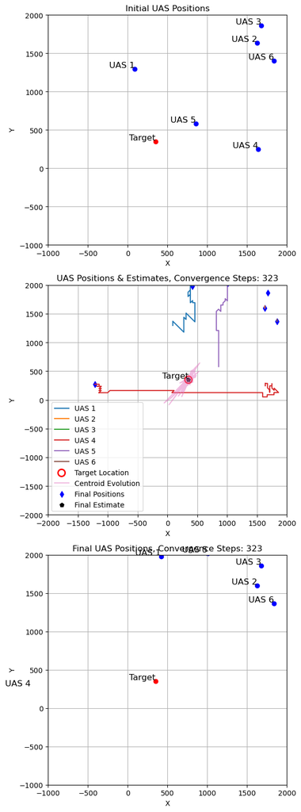

```python
print("Initial Drone-to-Target Distances\n",np.round(env.initial_drones_location2,2))
print("Final Drone Locations\n", env.drones_location)
plot_locations(env.initial_loc, env.drones_location, env.target_location, env.current_step)
```

```python
results_df = pd.DataFrame({'Num_Steps': ls_numsteps, 'Median_Error': ls_median_err, 'Median_CEP': ls_median_cep,
                           'Median_X': ls_med_x, 'Median_Y': ls_med_y, 'MAD_X': ls_mad_x, 'MAD_Y': ls_mad_y,
                          'Mean_X': ls_mean_x, 'Mean_Y': ls_mean_y, 'Std_X': ls_stddev_x, 'Std_Y': ls_stddev_y,
                          'Distance_Moved': ls_totaldistmoved, 'TotalReward': total_rewards_per_simulation} )
results_df.describe().style.format("{:.2f}")
```

|  | Num_Steps | Median_Error | Median_CEP | Median_X | Median_Y | MAD_X | MAD_Y | Mean_X | Mean_Y | Std_X | Std_Y | Distance_Moved | TotalReward |
| --- | --- | --- | --- | --- | --- | --- | --- | --- | --- | --- | --- | --- | --- |
| count | 1.00 | 1.00 | 1.00 | 1.00 | 1.00 | 1.00 | 1.00 | 1.00 | 1.00 | 1.00 | 1.00 | 1.00 | 1.00 |
| mean | 323.00 | 1.78 | 0.91 | 351.26 | 330.35 | 0.53 | 0.74 | 349.86 | 329.75 | 5.59 | 2.60 | 7543.87 | -131.00 |
| std | nan | nan | nan | nan | nan | nan | nan | nan | nan | nan | nan | nan | nan |
| min | 323.00 | 1.78 | 0.91 | 351.26 | 330.35 | 0.53 | 0.74 | 349.86 | 329.75 | 5.59 | 2.60 | 7543.87 | -131.00 |
| 25% | 323.00 | 1.78 | 0.91 | 351.26 | 330.35 | 0.53 | 0.74 | 349.86 | 329.75 | 5.59 | 2.60 | 7543.87 | -131.00 |
| 50% | 323.00 | 1.78 | 0.91 | 351.26 | 330.35 | 0.53 | 0.74 | 349.86 | 329.75 | 5.59 | 2.60 | 7543.87 | -131.00 |
| 75% | 323.00 | 1.78 | 0.91 | 351.26 | 330.35 | 0.53 | 0.74 | 349.86 | 329.75 | 5.59 | 2.60 | 7543.87 | -131.00 |
| max | 323.00 | 1.78 | 0.91 | 351.26 | 330.35 | 0.53 | 0.74 | 349.86 | 329.75 | 5.59 | 2.60 | 7543.87 | -131.00 |

```python
import pandas as pd

results_df = pd.DataFrame({'Num_Steps': ls_numsteps, 'Median_Error': ls_median_err, 'Median_CEP': ls_median_cep,
                           'Median_X': ls_med_x, 'Median_Y': ls_med_y, 'MAD_X': ls_mad_x, 'MAD_Y': ls_mad_y,
                          'Mean_X': ls_mean_x, 'Mean_Y': ls_mean_y, 'Std_X': ls_stddev_x, 'Std_Y': ls_stddev_y,
                          'Distance_Moved': ls_totaldistmoved, 'TotalReward': total_rewards_per_simulation} )

#results_df.to_csv('iter3_1_bvm1_corr_results10000a.csv', index=False)
flattened_locations = [array.flatten() for array in ls_locations]
# Create a DataFrame from the flattened data
final_locations_list = pd.DataFrame(flattened_locations, columns=[
    'Drone1_x', 'Drone1_y', 'Drone2_x', 'Drone2_y', 'Drone3_x', 'Drone3_y',
    'Drone4_x', 'Drone4_y', 'Drone5_x', 'Drone5_y', 'Drone6_x', 'Drone6_y'
    ])
#final_locations_list.to_csv('iter3_1_locations_10000.csv', index=False)

# Target location
target_loc = np.array([350, 350])

# Function to calculate Euclidean distance
def calculate_distance(row):
    distances = []
    for i in range(1, 7):  # Assuming 6 drones
        x = row[f'Drone{i}_x']
        y = row[f'Drone{i}_y']
        distance = np.sqrt((x - target_loc[0])**2 + (y - target_loc[1])**2)
        distances.append(distance)
    return distances

# Apply the function to each row of the DataFrame and create a new DataFrame
distance_data = final_locations_list.apply(calculate_distance, axis=1, result_type='expand')
distance_data.columns = [f'Drone{i}_Distance' for i in range(1, 7)]
#distance_data.to_csv('iter3_1_distances_10000.csv', index=False)

results_df = pd.read_csv('iter3_1_bvm1_corr_results10000_fin.csv')
results_df.describe().style.format("{:.2f}")
```

|  | Num_Steps | Median_Error | Median_CEP | Median_X | Median_Y | MAD_X | MAD_Y | Mean_X | Mean_Y | Std_X | Std_Y | Distance_Moved | TotalReward |
| --- | --- | --- | --- | --- | --- | --- | --- | --- | --- | --- | --- | --- | --- |
| count | 10000.00 | 10000.00 | 10000.00 | 10000.00 | 10000.00 | 10000.00 | 10000.00 | 10000.00 | 10000.00 | 10000.00 | 10000.00 | 10000.00 | 10000.00 |
| mean | 219.84 | 19.94 | 6.74 | 351.80 | 353.63 | 3.72 | 4.98 | 351.64 | 349.80 | 90.73 | 107.63 | 8490.40 | 182.86 |
| std | 247.29 | 28.61 | 56.42 | 24.59 | 111.93 | 19.60 | 52.97 | 374.78 | 479.21 | 1787.06 | 1622.86 | 2059.70 | 265.33 |
| min | 1.00 | 0.00 | 0.01 | -48.54 | -410.41 | 0.00 | 0.00 | -14938.45 | -39948.36 | 0.07 | 0.01 | 3233.13 | -907.00 |
| 25% | 60.00 | 5.60 | 1.00 | 342.25 | 343.64 | 0.61 | 0.51 | 341.37 | 342.77 | 2.88 | 2.70 | 7064.47 | 57.00 |
| 50% | 126.00 | 12.36 | 1.43 | 350.69 | 350.56 | 0.96 | 0.83 | 350.81 | 350.68 | 5.92 | 5.89 | 8388.70 | 128.00 |
| 75% | 270.00 | 24.03 | 1.76 | 359.68 | 358.00 | 1.34 | 1.21 | 360.75 | 359.27 | 16.10 | 16.39 | 9762.20 | 249.00 |
| max | 1000.00 | 563.62 | 3724.35 | 727.60 | 7978.50 | 503.82 | 3722.18 | 29151.83 | 7589.89 | 150870.31 | 116926.09 | 63939.29 | 3058.00 |

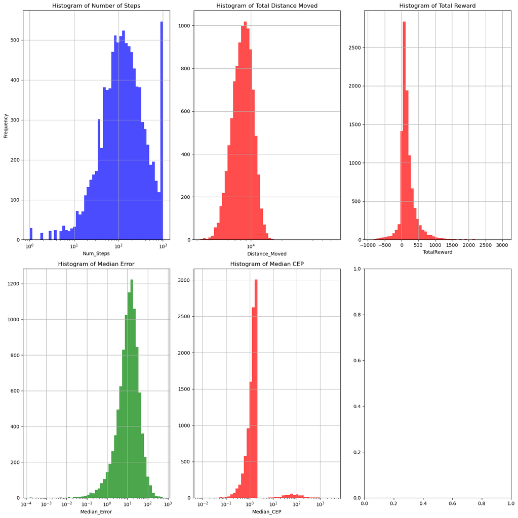

```python
# Create a figure and an array of subplots with 1 row and 3 columns
fig, axes = plt.subplots(2, 3, figsize=(15, 15))
bincount = 50
log_bins = np.logspace(np.log10(results_df['Num_Steps'].min()), np.log10(results_df['Num_Steps'].max()), bincount)


# Plot data
results_df['Num_Steps'].hist(ax=axes[0][0], bins=log_bins, color='blue', alpha=0.7)
axes[0][0].set_title('Histogram of Number of Steps')
axes[0][0].set_xlabel('Num_Steps')
axes[0][0].set_ylabel('Frequency')
axes[0][0].set_xscale('log')

log_bins = np.logspace(np.log10(results_df['Distance_Moved'].min()), np.log10(results_df['Distance_Moved'].max()), bincount)

results_df['Distance_Moved'].hist(ax=axes[0][1], bins=log_bins, color='red', alpha=0.7)
axes[0][1].set_title('Histogram of Total Distance Moved')
axes[0][1].set_xlabel('Distance_Moved')
axes[0][1].set_xscale('log')


results_df['TotalReward'].hist(ax=axes[0][2], bins=bincount, color='red', alpha=0.7)
axes[0][2].set_title('Histogram of Total Reward')
axes[0][2].set_xlabel('TotalReward')

log_bins = np.logspace(np.log10(results_df['Median_Error'].min()), np.log10(results_df['Median_Error'].max()), bincount)


results_df['Median_Error'].hist(ax=axes[1][0], bins=log_bins, color='green', alpha=0.7)
axes[1][0].set_title('Histogram of Median Error')
axes[1][0].set_xlabel('Median_Error')
axes[1][0].set_xscale('log')

log_bins = np.logspace(np.log10(results_df['Median_CEP'].min()), np.log10(results_df['Median_CEP'].max()), bincount)

results_df['Median_CEP'].hist(ax=axes[1][1], bins=log_bins, color='red', alpha=0.7)
axes[1][1].set_title('Histogram of Median CEP')
axes[1][1].set_xlabel('Median_CEP')
axes[1][1].set_xscale('log')


# Adjust layout to prevent overlap
plt.tight_layout()

# Show the plot
plt.show()
```

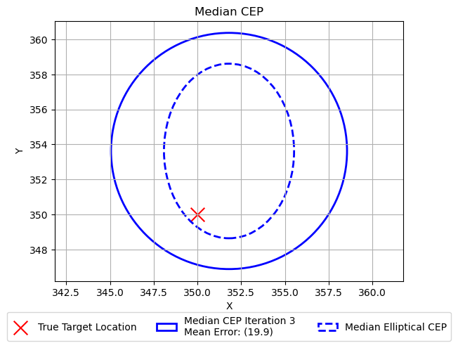

```python
mean_num_steps = results_df['Num_Steps'].mean()
mean_median_error = results_df['Median_Error'].mean()
mean_median_cep = results_df['Median_CEP'].mean()
mean_median_x = results_df['Median_X'].mean()
mean_median_y = results_df['Median_Y'].mean()
mean_mad_x = results_df['MAD_X'].mean()
mean_mad_y = results_df['MAD_Y'].mean()
mean_mean_x = results_df['Mean_X'].mean()
mean_mean_y = results_df['Mean_Y'].mean()
mean_std_x = results_df['Std_X'].mean()
mean_std_y = results_df['Std_Y'].mean()

# Plot Results
plt.scatter(env.target_location[0][0],env.target_location[0][1],color='red', label='True Target Location', marker='x',s=200)

# Plot circle using MAD deviations of x & y values
radius = mean_median_cep
median_cep_legend1 = f'Median CEP Iteration 3 \nMean Error: ({np.round(mean_median_error,1)})'
circle_median = Ellipse((mean_median_x, mean_median_y), 2*radius, 2*radius, edgecolor='blue', facecolor='none', linestyle='-', linewidth=2, label=median_cep_legend1)
plt.gca().add_patch(circle_median)

# Plot ellipse using median absolute distance values
median_cep_legend = f'Median Elliptical CEP'# ({np.round(mean_mad_x, 2)}, {np.round(mean_mad_y, 2)})'
ellipse_median = Ellipse((mean_median_x, mean_median_y), 2*mean_mad_x, 2*mean_mad_y, edgecolor='blue', facecolor='none', linestyle='--', linewidth=2, label=median_cep_legend)
plt.gca().add_patch(ellipse_median)

# Plot circle using std deviations of x & y values
radius = np.sqrt(mean_std_x**2 + mean_std_y**2)
mean_cep_legend = f'$\mu$ CEP ({np.round(radius,2)})'
circle_mean = Ellipse((mean_mean_x, mean_mean_y), 2*radius, 2*radius, edgecolor='green', facecolor='none', linestyle='-', linewidth=2, label=mean_cep_legend)
#plt.gca().add_patch(circle_mean)

# Plot ellipse using standard deviations
std_cep_legend = f'$\sigma$ Elliptical CEP ({np.round(mean_std_x, 2)}, {np.round(mean_std_y, 2)})'
ellipse_std = Ellipse((mean_mean_x, mean_mean_y), 2*mean_std_x, 2*mean_std_y, edgecolor='green', facecolor='none', linestyle='--', linewidth=2, label=std_cep_legend)
#plt.gca().add_patch(ellipse_std)

plt.xlabel('X')
plt.ylabel('Y')
plt.title('Median CEP')
plt.legend(
    loc='lower center',
    bbox_to_anchor=(0.5, -.25),
    ncol=3,
)
plt.grid(True)
plt.axis('equal')  # Equal aspect ratio
plt.show()
```

## Iteration 4:

*Iteration 4 - optional*

An optional fourth iteration, contingent on time constraints, combines elements from the first and third iterations. It seeks to minimize the error ellipse radius while maximizing RSS, using a weighted approach to balance both factors.

*Success Metric*

The success of each iteration is measured by the decreasing radius of the error ellipse and the reduction in the Euclidean distance between the center of this ellipse and the true target position. The system iterates until it reaches a predefined number of steps, a time limit, or the emitter is within a specified radius, indicating successful localization. We keep this metric the same across all iterations in order to maintain a fair comparison of success.

Additionally, the system's robustness and accuracy will be tested through Monte Carlo simulations with a series of initial positions to validate the localization estimates against the true target location. Each iteration will be conducted in 2 dimensional environments, where mostly zero-mean Gaussian-distributed error is added to the TOA, $\epsilon_t$ with $\sigma^2 = 10 ns$, to the individual sensor positions, with $\epsilon_x, \epsilon_y, \epsilon_z$ having $\sigma^2 = 2 cm$, including additional time delay due to multipath, with $\epsilon_n$ as $\sigma^2 = 10 ns$, and including a corresponding RSS noise value for multipath & signal fading, $\epsilon_p$ as $\mu = 3 dB$ and $\sigma^2 = 5 dB$.

```python
class DroneEnv(AECEnv):
    def __init__(self, num_drones):
        super().__init__()
        self.width = 2000
        self.height = self.width
        self.max_steps = 1000
        self.current_step = 0
        self.LOCASoln = []
        self.cep_radius_after = []

        # Currently setting this to fixed value to compare approaches
        self.targ_loc2 = np.array([[350,  350]])
        self.target_location = self.targ_loc2.copy()

        # Uncomment this line if we want to vary target from run-to-run
        #self.target_location = np.random.randint(50, self.width, size=(1, 2))

        # Currently setting this to fixed value to compare approaches
        self.num_drones = num_drones
        #self.initial_drones_location2 = np.array(([[483, 259], [271, 478],[238,  75],[469, 157], [191, 201], [ 96, 195]]))
        #self.initial_drones_location2 = np.array(([[700, 100], [271, 478],[300,  75],[650, 650], [191, 701], [ 96, 195]]))
        self.initial_drones_location2 = np.random.randint(50, self.width, size=(self.num_drones, 2))

        # or use
        if np.size(self.initial_drones_location2,0) < self.num_drones:
            self.initial_drones_location2 = np.random.randint(50, self.width, size=(self.num_drones, 2))

        self.drones_location =  self.initial_drones_location2.copy()

        self.initial_loc = self.initial_drones_location2.copy()
        # Uncomment this line if we want to vary initial locations from run-to-run
        #self.initial_loc = self.drones_location.copy()

        self.target_power = 10
        #print("Drones",self.drones_location)

        power_init = -1 * 20 * np.log10((4 * np.pi * 2*self.width * 5e9) / 3e8) +  self.target_power
        self.signal_strength = np.zeros(self.num_drones) + power_init
        self.drone_trajectory = [[] for _ in range(num_drones)]  # List to store trajectories for each drone

        self.metadata = {'render.modes': ['human']}

        self.action_space = Discrete(9)  # Discrete action space
        self.observation_space = Box(low=0, high=self.width, shape=(5,), dtype=np.float32)

        # Initialize Q-tables for each agent
        self.q_tables = [np.zeros((self.observation_space.shape[0], self.action_space.n)) for _ in range(num_drones)]

        self.alpha = 0.1  # Learning rate
        self.gamma = 0.9  # Discount factor
        self.epsilon = 0.1  # Epsilon for epsilon-greedy action selection

        self.loca_soln_avg =  np.random.randint(50, self.width, size=(1, 2))

        initial_distances = np.linalg.norm(self.target_location - self.initial_loc, axis=1)
        toas = initial_distances/(3e8) # Convert Distance to Time

        drones_location_err = np.zeros((self.num_drones,2))

        # Calculate LOCA Estimate
        for i in range(self.num_drones): # Add errors
            drones_location_err[i], toas[i] = add_errs(self.initial_loc[i],toas[i])

        LOCASoln = LOCAfun_allcombs_2D(drones_location_err, toas)
        std_x, std_y, mean_x, mean_y, median_x, median_y, mad_x, mad_y = calculate_elliptical_CEP(LOCASoln)

        #cep_radius = np.sqrt(std_x**2 + std_y**2)
        cep_radius = np.sqrt(mad_x**2 + mad_y**2)
        print("Initial CEP Radius", np.round(cep_radius))
        self.localization_est = np.array([[median_x,median_y]])
        self.loca_err =  np.linalg.norm(self.localization_est - self.target_location, axis=1)
        self.LOCASoln = LOCASoln.copy()
        self.cep_radius_after = cep_radius.copy()
        self.old_locs = drones_location_err

        self.centroids = []


    def observe(self, agent):
        return self.signal_strength[agent]


    def step(self, action):
        #print(f"Current Step: {self.current_step}")  # To track steps

        self.current_step += 1
        cp_prev = np.round(self.cep_radius_after,2)

        min_cep = 2
        ds = np.abs(np.round(((cp_prev-min_cep)/min_cep),2))


        movements = np.array([[0, ds], [0, -1*ds], [ds, 0], [-1*ds, 0], [0, 0], [ds,ds], [ds,-1*ds], [-1*ds,-1*ds], [-1*ds,-1*ds]])

        # Update drone positions based on actions and calculate new positions error
        drones_location_err = np.zeros((self.num_drones, 2))
        toas = np.zeros(self.num_drones)

        # Adding penalty for moving out of bounds
        #boundary_violation_penalty = -10 # Starting penalty
        boundary_violation_penalty = -1 # Starting penalty

        # Initialize rewards
        #rewards = np.full(self.num_drones, -1)  # Default to -1
        rewards = np.full(self.num_drones, 1)  # Default to 1

        distances_before_action = np.linalg.norm(self.target_location - self.drones_location, axis=1)
        toas = distances_before_action/(3e8) # Convert Distance to Time
        # Calculate LOCA Estimate
        for i in range(self.num_drones):
            drones_location_err[i], toas[i] = add_errs(self.drones_location[i],toas[i])

        LOCASoln = LOCAfun_allcombs_2D(drones_location_err, toas)
        std_x, std_y, mean_x, mean_y, median_x, median_y, mad_x, mad_y = calculate_elliptical_CEP(LOCASoln)
        localization_est_before = np.array([median_x,median_y])
        loca_err =  np.linalg.norm(localization_est_before - self.target_location, axis=1)

        # Calculate Power Before
        power_before = np.zeros(self.num_drones)  # Initialize power_before array
        for i in range(self.num_drones):
            distance = np.linalg.norm(self.target_location - self.drones_location[i])
            if distance == 0:
                received_power = self.target_power
            else:
                received_power = -1 * 20 * np.log10((4 * np.pi * distance * 5e9) / 3e8) + self.target_power

            # value for random error in received power to account for multipath & fading
            rss_err = abs(np.random.normal(loc=mean_rss_err, scale = stdev_rss_err))
            self.signal_strength[i] = received_power - rss_err
            power_before[i] = received_power  # Store received power in the array

        for i, act in enumerate(action):
            movement = movements[act]
```

```python
            #self.drones_location[i] += movement
        # Adjustment for out of bounds
            new_position = self.drones_location[i] + movement
            if np.linalg.norm(new_position - self.localization_est) > max_dist:
                rewards[i] += boundary_violation_penalty
                pass # do nothing: reject the move
            else:
                self.drones_location[i] = new_position

            self.drone_trajectory[i].append(self.drones_location[i].copy())
            # Calculate distance and time of arrival for new position
            distance = np.linalg.norm(self.target_location - self.drones_location[i])
            toas[i] = distance / 3e8
            drones_location_err[i], toas[i] = add_errs(self.drones_location[i], toas[i])

        # Recalculate LOCA solution and CEP after movements
        LOCASoln_after = LOCAfun_allcombs_2D(drones_location_err, toas)
        std_x, std_y, mean_x, mean_y, median_x, median_y, mad_x, mad_y = calculate_elliptical_CEP(LOCASoln_after)
        self.localization_est = np.array([median_x, median_y])
        self.LOCASoln = LOCASoln_after
        self.centroids.append(self.localization_est.copy())

        #cep_radius = np.sqrt(std_x**2 + std_y**2)
        cep_radius_after = np.sqrt(mad_x**2 + mad_y**2)
        self.totaldistmoved = np.sum(np.sqrt(np.sum((drones_location_err-self.old_locs)**2, axis=1)))

        # Caclulate Power After Action
        power_after = np.zeros(self.num_drones)  # Initialize power_after array
        for i in range(self.num_drones):
            distance = np.linalg.norm(self.target_location - self.drones_location[i])
            if distance == 0:
                received_power = self.target_power
            else:
                received_power = -1 * 20 * np.log10((4 * np.pi * distance * 5e9) / 3e8) + self.target_power

            # value for random error in received power to account for multipath & fading
            rss_err = abs(np.random.normal(loc=mean_rss_err, scale = stdev_rss_err))

            self.signal_strength[i] =  received_power - rss_err
            power_after[i] = received_power  # Store received power in the array

        rewards_power = np.where(power_after > power_before, 1, -1)

        # Calculate CEP before movements using the previous LOCA solution
      #  std_x_before, std_y_before, mean_x_before, mean_y_before, median_x_before, median_y_before, mad_x_before, mad_y_before = calculate_elliptical_CEP(self.LOCASoln)
        #cep_radius_before = np.sqrt(std_x**2 + std_y**2)
       # cep_radius_before = np.sqrt(mad_x**2 + mad_y**2)

        # Generate combels_all dynamically based on the number of drones
        combels_all = generate_combinations(self.num_drones)

        # Calculate distances of LOCASoln to the centroid
        distances = np.linalg.norm(self.LOCASoln - self.localization_est, axis=1)

        # Calculate drone contributions
        num2move = 1  # Number of drones you want to consider for movement
        worst_indices = calculate_drone_contributions(combels_all, distances, num2move, self.num_drones)


        for idx in worst_indices:
            #rewards[idx] = 1  # Reward the drones that are most off
            rewards[idx] = -1  # Discount the drones that are most off

        rewards_cep = rewards.copy()

        rewards = 0.5*rewards_power + 0.5*rewards_cep


        # Check for termination conditions
        done_max_steps = self.current_step >= self.max_steps
        done_target_CEP = cep_radius_after <= min_cep
        done = done_max_steps or done_target_CEP
        #if done:
           # print("Final CEP radius: ", np.round(cep_radius_after,2))

       # print(f"CEP Radius Before: {cep_radius_before}, After: {cep_radius_after}")  # To track CEP changes
       # print(f"Termination Status: {done}")  # To confirm if 'done' is ever True


        # Update LOCA solution

        return self.drones_location, rewards, done, self.LOCASoln, {}

    def reset(self):
        self.initial_loc =  np.random.randint(50, self.width, size=(self.num_drones, 2))
        self.drones_location = self.initial_loc.copy()#np.random.randint(0, self.width, size=(self.num_drones, 2))
        self.signal_strength = np.zeros(self.num_drones) - 200
        self.current_step = 0
        power_init = -1 * 20 * np.log10((4 * np.pi * 2*self.width * 5e9) / 3e8) +  self.target_power
        self.signal_strength = np.zeros(self.num_drones) + power_init
        self.q_tables = [np.zeros((self.observation_space.shape[0], self.action_space.n)) for _ in range(num_drones)]
        self.loca_soln_avg =  np.random.randint(50, self.width, size=(1, 2))

        initial_distances = np.linalg.norm(self.target_location - self.initial_loc, axis=1)
        toas = initial_distances/(3e8) # Convert Distance to Time

        drones_location_err = np.zeros((self.num_drones,2))

        # Calculate LOCA Estimate
        for i in range(self.num_drones): # Add errors
            drones_location_err[i], toas[i] = add_errs(self.initial_loc[i],toas[i])

        LOCASoln = LOCAfun_allcombs_2D(drones_location_err, toas)
        std_x, std_y, mean_x, mean_y, median_x, median_y, mad_x, mad_y = calculate_elliptical_CEP(LOCASoln)

        #cep_radius = np.sqrt(std_x**2 + std_y**2) / 2
        cep_radius = np.sqrt(mad_x**2 + mad_y**2)
       #print("Initial CEP Radius", np.round(cep_radius))
        self.localization_est = np.array([[median_x,median_y]])
        self.loca_err =  np.linalg.norm(self.localization_est - self.target_location, axis=1)
        self.LOCASoln = LOCASoln.copy()
        self.cep_radius_after = cep_radius.copy()


        for i in range(self.num_drones):
            self.drone_trajectory[i] = [np.copy(self.drones_location[i])]  # Reset drone trajectory
        return self.signal_strength


    def render(self, mode='human'):
        pass

    def update_q_table(self, agent, state, action, reward, next_state):
        old_q_value = self.q_tables[agent][state, action]
        next_max_q_value = np.max(self.q_tables[agent][next_state])
        new_q_value = old_q_value + self.alpha * (reward + self.gamma * next_max_q_value - old_q_value)
        self.q_tables[agent][state, action] = new_q_value
```

```python
    def choose_action(self, agent, state):
        if np.random.rand() < self.epsilon:
            #print("Exploration")
            action_out = np.random.randint(self.action_space.n) % 9
            return  action_out # Exploration
        else:
            #print("Exploitation")
            action_out = np.argmax(self.q_tables[agent][state]) % 9
            return action_out  # Exploitation

    def convert_state_to_int(self, state):
        # Use modulo operation to ensure the state representation falls within the valid range
        npsst = np.sum(state)
        if npsst > 10000: npsst = 10000
        elif npsst < -10000: npsst = -1000
        else: npsst = npsst
        return int(npsst) % self.observation_space.shape[0]
```

```
Initial CEP Radius 44.0
Initial Drone-to-Target Distances
 [[1503  936]
 [ 946 1176]
 [1422 1841]
 [ 924  980]
 [ 643  942]
 [ 439 1157]]
Final Drone Locations
 [[1607  300]
 [-624  223]
 [1422 1841]
 [-540  654]
 [ 642   -7]
 [ 439 -103]]
```

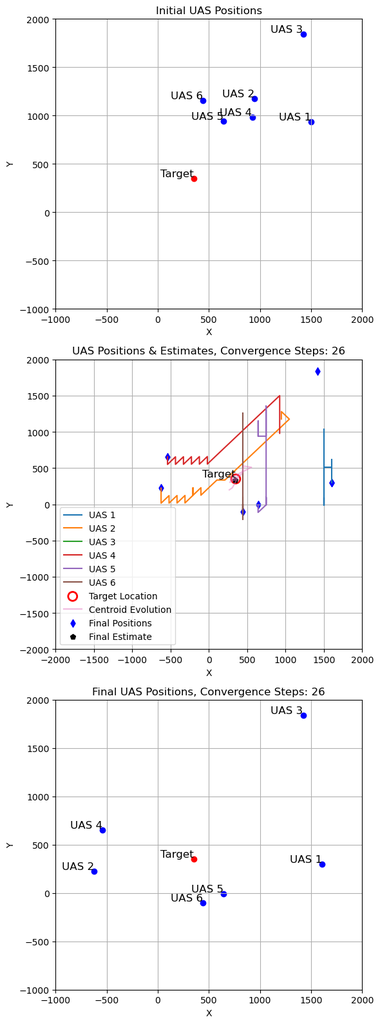

```python
import time
start_time = time.time()

# Number of drones (agents)
num_drones = 6
env = DroneEnv(num_drones)
num_simulations = 1
DEBUG=False

ls_numsteps =[]
ls_median_cep =[]
ls_median_err=[]

ls_stddev_x =[]
ls_stddev_y =[]
ls_mean_x=[]
ls_mean_y=[]
ls_med_x=[]
ls_med_y=[]
ls_mad_x=[]
ls_mad_y=[]
ls_totaldistmoved = []
total_rewards_per_simulation = []
ls_locations = []


for i in range(num_simulations):
    obs = env.reset()
    initial_drones_location = env.drones_location  # Initial drone positions
    total_reward = 0

    if DEBUG: print('Initial LOCA Target Estimate: ', np.round(env.localization_est,2))
    if DEBUG: print('Initial LOCA Error (m): ', np.round(env.loca_err,2))
    initial_LOCA = env.LOCASoln
    initial_distances = np.linalg.norm(env.target_location - env.initial_loc, axis=1)

    for _ in range(1000):
        actions = [env.choose_action(agent, env.convert_state_to_int(env.drones_location[agent])) for agent in range(num_drones)]
        next_obs, rewards, done, LOCASoln, _ = env.step(actions)

        total_reward += np.sum(rewards)

        for agent in range(num_drones):
            state = int(env.convert_state_to_int(env.drones_location[agent]))
            if DEBUG: print(f"Agent {agent + 1} state: {state}")  # Add this line to print the state
            action = actions[agent]
            next_state = env.convert_state_to_int(next_obs[agent])
            reward = rewards[agent]
            env.update_q_table(agent, state, action, reward, next_state)
        obs = next_obs
        if done:
            final_drones_location = env.drones_location
            final_distances = np.linalg.norm(env.target_location - env.drones_location, axis=1)
            final_loc = np.average(env.LOCASoln, axis = 0)

            loca_err =  np.linalg.norm(final_loc - env.target_location, axis = 1)
            estimated_positions = np.array(env.LOCASoln)
            break
    std_x, std_y, mean_x, mean_y, median_x, median_y, mad_x, mad_y = calculate_elliptical_CEP(estimated_positions)
    med_err =  np.linalg.norm(np.array(median_x,median_y)-env.target_location,axis = 1)
    if DEBUG: print("Standard Deviation (x,y):",  np.round(std_x,2),", ",np.round(std_y,2))
    if DEBUG: print("Median Absolute Distance  (x,y):", np.round(mad_x, 2),", ",np.round(mad_y,2))
    if DEBUG: print("Mean Target Estimate (x,y):", np.round(mean_x,2),", ",np.round(mean_y,2))
    if DEBUG: print("Median Target Estimate (x,y):", np.round(median_x, 2),", ",np.round(median_y,2))
    if DEBUG: print("Median Error:", np.round(med_err,2))

    if DEBUG: print('Final LOCA Target Estimate: ', np.round(final_loc,2))
    if DEBUG: print('Final LOCA Error (m): ', np.round(loca_err,2))

    if DEBUG: print("Initial Drone-to-Target Distances\n",np.round(initial_distances,2))
    if DEBUG: print("Final Drone-to-Target Distances\n",np.round(final_distances,2))
    if DEBUG: plot_locations(env.initial_loc, final_drones_location, env.target_location, env.current_step)

    if DEBUG: received_power_initial = -1 * 20 * np.log10((4 * np.pi * initial_distances * 5e9) / 3e8) + env.target_power
    if DEBUG: print("Initial Power",np.round(received_power_initial,2))
    if DEBUG: received_power_final = -1 * 20 * np.log10((4 * np.pi * final_distances * 5e9) / 3e8) + env.target_power
    if DEBUG: print("Final Power",np.round(received_power_final,2))
    if DEBUG: print("Power Improvement",np.round(received_power_final-received_power_initial,2))
    if DEBUG: print("Completion Steps: ", env.current_step)

    #save off values
    ls_numsteps.append(env.current_step)
    ls_median_err.append(med_err[-1])
    ls_median_cep.append(np.sqrt(mad_x**2 + mad_y**2))
    ls_totaldistmoved.append(env.totaldistmoved)
    total_rewards_per_simulation.append(total_reward)
    ls_locations.append(env.drones_location)

    # Optional:
    ls_stddev_x.append(np.round(std_x, 2))
    ls_stddev_y.append(np.round(std_y, 2))
    ls_med_x.append(np.round(median_x, 2))
    ls_med_y.append(np.round(median_y, 2))
    ls_mean_x.append(np.round(mean_x, 2))
    ls_mean_y.append(np.round(mean_y, 2))
    ls_mad_x.append(np.round(mad_x, 2))
    ls_mad_y.append(np.round(mad_y, 2))


    # Print progress every 25 steps
    if i % 100 == 1:
        current_time = time.time()
        elapsed_time = current_time - start_time
        avg_time_per_step = elapsed_time / i
        estimated_total_time = avg_time_per_step * num_simulations
        estimated_time_remaining = estimated_total_time - elapsed_time

        print(f"Step {i}/{num_simulations}")
        print(f"Time elapsed: {elapsed_time:.2f} seconds")
        print(f"Estimated time to complete: {estimated_time_remaining:.2f} seconds")

    if i == num_simulations:
        print("Done")


#print("Number of Steps: ", ls_numsteps)
#print("Median Error: ", np.round(ls_median_err,2))
#print("Median CEP: ", np.round(ls_median_cep,2))

# print(ls_stddev_x)
# print(ls_stddev_y)
# print(ls_mean_x)
# print(ls_mean_y)
# print(ls_med_x)
# print(ls_med_y)
# print(ls_mad_x)
# print(ls_mad_y)


print("Initial Drone-to-Target Distances\n",np.round(env.initial_loc,2))
print("Final Drone Locations\n", env.drones_location)
plot_locations(env.initial_loc, env.drones_location, env.target_location, env.current_step)
```

```
Initial Drone-to-Target Distances
 [[1503  936]
 [ 946 1176]
 [1422 1841]
 [ 924  980]
 [ 643  942]
 [ 439 1157]]
Final Drone Locations
 [[1607  300]
 [-624  223]
 [1422 1841]
 [-540  654]
 [ 642   -7]
 [ 439 -103]]
```

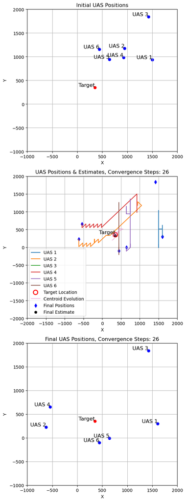

```python
print("Initial Drone-to-Target Distances\n",np.round(env.initial_loc,2))
print("Final Drone Locations\n", env.drones_location)
plot_locations(env.initial_loc, env.drones_location, env.target_location, env.current_step)
```

```python
import pandas as pd

results_df = pd.DataFrame({'Num_Steps': ls_numsteps, 'Median_Error': ls_median_err, 'Median_CEP': ls_median_cep,
                           'Median_X': ls_med_x, 'Median_Y': ls_med_y, 'MAD_X': ls_mad_x, 'MAD_Y': ls_mad_y,
                          'Mean_X': ls_mean_x, 'Mean_Y': ls_mean_y, 'Std_X': ls_stddev_x, 'Std_Y': ls_stddev_y,
                          'Distance_Moved': ls_totaldistmoved, 'TotalReward': total_rewards_per_simulation} )

#results_df.to_csv('iter4_1_bvm1_corr_results10000a.csv', index=False)
flattened_locations = [array.flatten() for array in ls_locations]
# Create a DataFrame from the flattened data
final_locations_list = pd.DataFrame(flattened_locations, columns=[
    'Drone1_x', 'Drone1_y', 'Drone2_x', 'Drone2_y', 'Drone3_x', 'Drone3_y',
    'Drone4_x', 'Drone4_y', 'Drone5_x', 'Drone5_y', 'Drone6_x', 'Drone6_y'
    ])
#final_locations_list.to_csv('iter4_1_locations_10000.csv', index=False)

# Target location
target_loc = np.array([350, 350])

# Function to calculate Euclidean distance
def calculate_distance(row):
    distances = []
    for i in range(1, 7):  # Assuming 6 drones
        x = row[f'Drone{i}_x']
        y = row[f'Drone{i}_y']
        distance = np.sqrt((x - target_loc[0])**2 + (y - target_loc[1])**2)
        distances.append(distance)
    return distances

# Apply the function to each row of the DataFrame and create a new DataFrame
distance_data = final_locations_list.apply(calculate_distance, axis=1, result_type='expand')
distance_data.columns = [f'Drone{i}_Distance' for i in range(1, 7)]
#distance_data.to_csv('iter4_1_distances_10000.csv', index=False)

results_df = pd.read_csv('iter4_1_bvm1_corr_results10000_fin.csv')
results_df.describe().style.format("{:.2f}")
```

|  | Num_Steps | Median_Error | Median_CEP | Median_X | Median_Y | MAD_X | MAD_Y | Mean_X | Mean_Y | Std_X | Std_Y | Distance_Moved | TotalReward |
| --- | --- | --- | --- | --- | --- | --- | --- | --- | --- | --- | --- | --- | --- |
| count | 10000.00 | 10000.00 | 10000.00 | 10000.00 | 10000.00 | 10000.00 | 10000.00 | 10000.00 | 10000.00 | 10000.00 | 10000.00 | 10000.00 | 10000.00 |
| mean | 129.19 | 13.70 | 2.38 | 350.62 | 349.64 | 1.40 | 1.73 | 352.67 | 350.70 | 46.62 | 47.84 | 7740.50 | 112.67 |
| std | 143.90 | 19.30 | 29.67 | 16.73 | 20.89 | 9.25 | 28.20 | 173.06 | 164.40 | 881.52 | 769.26 | 1923.34 | 157.06 |
| min | 1.00 | 0.00 | 0.02 | -113.52 | -741.42 | 0.01 | 0.01 | -3447.67 | -5457.98 | 0.04 | 0.05 | 1832.39 | -826.00 |
| 25% | 48.00 | 4.17 | 0.99 | 343.90 | 343.46 | 0.56 | 0.55 | 343.32 | 342.87 | 2.61 | 2.50 | 6304.24 | 35.00 |
| 50% | 86.00 | 9.12 | 1.40 | 350.13 | 349.63 | 0.89 | 0.87 | 350.08 | 349.67 | 5.16 | 4.96 | 7614.25 | 76.00 |
| 75% | 154.00 | 16.99 | 1.73 | 356.78 | 355.91 | 1.24 | 1.21 | 357.48 | 356.40 | 12.40 | 11.93 | 9060.49 | 147.25 |
| max | 1000.00 | 734.82 | 2573.11 | 869.59 | 620.09 | 528.22 | 2518.30 | 11198.55 | 10300.59 | 57496.23 | 44442.38 | 22192.14 | 2424.00 |

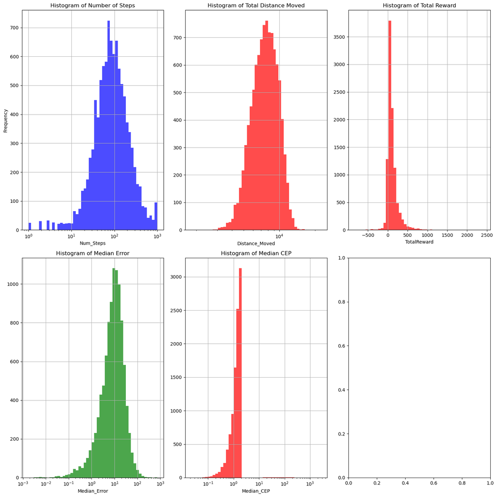

```python
# Create a figure and an array of subplots with 1 row and 3 columns
fig, axes = plt.subplots(2, 3, figsize=(15, 15))
bincount = 50
log_bins = np.logspace(np.log10(results_df['Num_Steps'].min()), np.log10(results_df['Num_Steps'].max()), bincount)


# Plot data
results_df['Num_Steps'].hist(ax=axes[0][0], bins=log_bins, color='blue', alpha=0.7)
axes[0][0].set_title('Histogram of Number of Steps')
axes[0][0].set_xlabel('Num_Steps')
axes[0][0].set_ylabel('Frequency')
axes[0][0].set_xscale('log')

log_bins = np.logspace(np.log10(results_df['Distance_Moved'].min()), np.log10(results_df['Distance_Moved'].max()), bincount)

results_df['Distance_Moved'].hist(ax=axes[0][1], bins=log_bins, color='red', alpha=0.7)
axes[0][1].set_title('Histogram of Total Distance Moved')
axes[0][1].set_xlabel('Distance_Moved')
axes[0][1].set_xscale('log')


results_df['TotalReward'].hist(ax=axes[0][2], bins=bincount, color='red', alpha=0.7)
axes[0][2].set_title('Histogram of Total Reward')
axes[0][2].set_xlabel('TotalReward')

log_bins = np.logspace(np.log10(results_df['Median_Error'].min()), np.log10(results_df['Median_Error'].max()), bincount)


results_df['Median_Error'].hist(ax=axes[1][0], bins=log_bins, color='green', alpha=0.7)
axes[1][0].set_title('Histogram of Median Error')
axes[1][0].set_xlabel('Median_Error')
axes[1][0].set_xscale('log')

log_bins = np.logspace(np.log10(results_df['Median_CEP'].min()), np.log10(results_df['Median_CEP'].max()), bincount)

results_df['Median_CEP'].hist(ax=axes[1][1], bins=log_bins, color='red', alpha=0.7)
axes[1][1].set_title('Histogram of Median CEP')
axes[1][1].set_xlabel('Median_CEP')
axes[1][1].set_xscale('log')


# Adjust layout to prevent overlap
plt.tight_layout()

# Show the plot
plt.show()
```

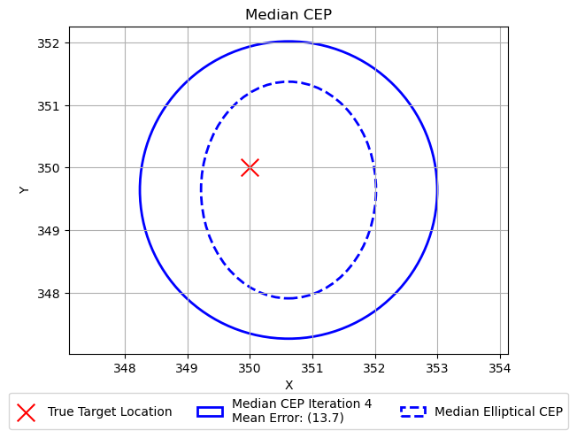

```python
mean_num_steps = results_df['Num_Steps'].mean()
mean_median_error = results_df['Median_Error'].mean()
mean_median_cep = results_df['Median_CEP'].mean()
mean_median_x = results_df['Median_X'].mean()
mean_median_y = results_df['Median_Y'].mean()
mean_mad_x = results_df['MAD_X'].mean()
mean_mad_y = results_df['MAD_Y'].mean()
mean_mean_x = results_df['Mean_X'].mean()
mean_mean_y = results_df['Mean_Y'].mean()
mean_std_x = results_df['Std_X'].mean()
mean_std_y = results_df['Std_Y'].mean()

# Plot Results
plt.scatter(env.target_location[0][0],env.target_location[0][1],color='red', label='True Target Location', marker='x',s=200)

# Plot circle using MAD deviations of x & y values
radius = mean_median_cep
median_cep_legend1 = f'Median CEP Iteration 4 \nMean Error: ({np.round(mean_median_error,1)})'
circle_median = Ellipse((mean_median_x, mean_median_y), 2*radius, 2*radius, edgecolor='blue', facecolor='none', linestyle='-', linewidth=2, label=median_cep_legend1)
plt.gca().add_patch(circle_median)

# Plot ellipse using median absolute distance values
median_cep_legend = f'Median Elliptical CEP'# ({np.round(mean_mad_x, 2)}, {np.round(mean_mad_y, 2)})'
ellipse_median = Ellipse((mean_median_x, mean_median_y), 2*mean_mad_x, 2*mean_mad_y, edgecolor='blue', facecolor='none', linestyle='--', linewidth=2, label=median_cep_legend)
plt.gca().add_patch(ellipse_median)

# Plot circle using std deviations of x & y values
radius = np.sqrt(mean_std_x**2 + mean_std_y**2)
mean_cep_legend = f'$\mu$ CEP ({np.round(radius,2)})'
circle_mean = Ellipse((mean_mean_x, mean_mean_y), 2*radius, 2*radius, edgecolor='green', facecolor='none', linestyle='-', linewidth=2, label=mean_cep_legend)
#plt.gca().add_patch(circle_mean)

# Plot ellipse using standard deviations
std_cep_legend = f'$\sigma$ Elliptical CEP ({np.round(mean_std_x, 2)}, {np.round(mean_std_y, 2)})'
ellipse_std = Ellipse((mean_mean_x, mean_mean_y), 2*mean_std_x, 2*mean_std_y, edgecolor='green', facecolor='none', linestyle='--', linewidth=2, label=std_cep_legend)
#plt.gca().add_patch(ellipse_std)

plt.xlabel('X')
plt.ylabel('Y')
plt.title('Median CEP')
plt.legend(
    loc='lower center',
    bbox_to_anchor=(0.5, -.25),
    ncol=3,
)
plt.grid(True)
plt.axis('equal')  # Equal aspect ratio
plt.show()
```

## Summary of Results

```python
results_iter1 = pd.read_csv('iter1_results10000_fin.csv')
results_iter1.describe().style.format("{:.2f}")
```

|  | Num_Steps | Median_Error | Median_CEP | Median_X | Median_Y | MAD_X | MAD_Y | Mean_X | Mean_Y | Std_X | Std_Y | Distance_Moved | TotalReward |
| --- | --- | --- | --- | --- | --- | --- | --- | --- | --- | --- | --- | --- | --- |
| count | 10000.00 | 10000.00 | 10000.00 | 10000.00 | 10000.00 | 10000.00 | 10000.00 | 10000.00 | 10000.00 | 10000.00 | 10000.00 | 10000.00 | 10000.00 |
| mean | 118.00 | 12.74 | 3.19 | 350.04 | 349.27 | 2.06 | 2.28 | 353.59 | 344.83 | 59.79 | 49.37 | 10007.55 | 122.56 |
| std | 121.76 | 45.05 | 105.28 | 33.10 | 63.46 | 63.44 | 84.02 | 719.47 | 684.91 | 1403.12 | 1068.00 | 17378.50 | 251.49 |
| min | 1.00 | 0.00 | 0.02 | -1764.57 | -5138.72 | 0.01 | 0.01 | -14924.57 | -65537.04 | 0.06 | 0.03 | 2864.99 | -1414.00 |
| 25% | 46.00 | 3.31 | 1.00 | 344.82 | 343.92 | 0.53 | 0.58 | 343.97 | 343.26 | 2.60 | 2.67 | 6340.95 | 15.50 |
| 50% | 85.00 | 7.38 | 1.41 | 349.87 | 350.10 | 0.84 | 0.92 | 349.88 | 350.12 | 5.23 | 5.20 | 7431.46 | 76.00 |
| 75% | 146.00 | 14.34 | 1.73 | 355.28 | 356.32 | 1.18 | 1.27 | 356.09 | 357.04 | 12.74 | 12.39 | 9162.02 | 182.00 |
| max | 1000.00 | 2990.46 | 10310.58 | 2169.62 | 790.22 | 6141.48 | 8281.93 | 68283.74 | 16542.28 | 79885.41 | 73506.50 | 579404.52 | 3640.00 |

```python
results_iter2 = pd.read_csv('iter2_results10000_fin.csv')
results_iter2.describe().style.format("{:.2f}")
```

|  | Num_Steps | Median_Error | Median_CEP | Median_X | Median_Y | MAD_X | MAD_Y | Mean_X | Mean_Y | Std_X | Std_Y | Distance_Moved | TotalReward |
| --- | --- | --- | --- | --- | --- | --- | --- | --- | --- | --- | --- | --- | --- |
| count | 10000.00 | 10000.00 | 10000.00 | 10000.00 | 10000.00 | 10000.00 | 10000.00 | 10000.00 | 10000.00 | 10000.00 | 10000.00 | 10000.00 | 10000.00 |
| mean | 165.41 | 17.66 | 6.50 | 350.79 | 349.51 | 4.19 | 4.36 | 338.96 | 346.14 | 188.77 | 111.79 | 12100.01 | -1.56 |
| std | 192.49 | 63.29 | 78.99 | 46.46 | 57.77 | 54.81 | 56.93 | 2334.86 | 910.41 | 8301.87 | 2998.90 | 22363.50 | 104.12 |
| min | 1.00 | 0.00 | 0.02 | -1171.48 | -2950.14 | 0.01 | 0.01 | -199466.76 | -73245.21 | 0.04 | 0.05 | 2885.16 | -1300.00 |
| 25% | 54.00 | 4.03 | 0.99 | 343.70 | 343.48 | 0.56 | 0.55 | 343.17 | 342.86 | 2.66 | 2.47 | 6304.95 | -26.00 |
| 50% | 102.00 | 9.10 | 1.41 | 349.98 | 350.15 | 0.89 | 0.88 | 350.02 | 350.02 | 5.45 | 5.08 | 7661.82 | 14.00 |
| 75% | 194.00 | 17.97 | 1.74 | 356.59 | 356.77 | 1.24 | 1.24 | 357.35 | 357.57 | 13.76 | 12.58 | 10663.44 | 52.00 |
| max | 1000.00 | 3993.79 | 4381.00 | 3174.04 | 2776.50 | 3664.58 | 2582.46 | 116816.90 | 39598.88 | 739780.28 | 216649.97 | 879449.49 | 494.00 |

```python
results_iter3 = pd.read_csv('iter3_1_bvm1_corr_results10000_fin.csv')
results_iter3.describe().style.format("{:.2f}")
```

|  | Num_Steps | Median_Error | Median_CEP | Median_X | Median_Y | MAD_X | MAD_Y | Mean_X | Mean_Y | Std_X | Std_Y | Distance_Moved | TotalReward |
| --- | --- | --- | --- | --- | --- | --- | --- | --- | --- | --- | --- | --- | --- |
| count | 10000.00 | 10000.00 | 10000.00 | 10000.00 | 10000.00 | 10000.00 | 10000.00 | 10000.00 | 10000.00 | 10000.00 | 10000.00 | 10000.00 | 10000.00 |
| mean | 219.84 | 19.94 | 6.74 | 351.80 | 353.63 | 3.72 | 4.98 | 351.64 | 349.80 | 90.73 | 107.63 | 8490.40 | 182.86 |
| std | 247.29 | 28.61 | 56.42 | 24.59 | 111.93 | 19.60 | 52.97 | 374.78 | 479.21 | 1787.06 | 1622.86 | 2059.70 | 265.33 |
| min | 1.00 | 0.00 | 0.01 | -48.54 | -410.41 | 0.00 | 0.00 | -14938.45 | -39948.36 | 0.07 | 0.01 | 3233.13 | -907.00 |
| 25% | 60.00 | 5.60 | 1.00 | 342.25 | 343.64 | 0.61 | 0.51 | 341.37 | 342.77 | 2.88 | 2.70 | 7064.47 | 57.00 |
| 50% | 126.00 | 12.36 | 1.43 | 350.69 | 350.56 | 0.96 | 0.83 | 350.81 | 350.68 | 5.92 | 5.89 | 8388.70 | 128.00 |
| 75% | 270.00 | 24.03 | 1.76 | 359.68 | 358.00 | 1.34 | 1.21 | 360.75 | 359.27 | 16.10 | 16.39 | 9762.20 | 249.00 |
| max | 1000.00 | 563.62 | 3724.35 | 727.60 | 7978.50 | 503.82 | 3722.18 | 29151.83 | 7589.89 | 150870.31 | 116926.09 | 63939.29 | 3058.00 |

```python
results_iter4 = pd.read_csv('iter4_1_bvm1_corr_results10000_fin.csv')
results_iter4.describe().style.format("{:.2f}")
```

|  | Num_Steps | Median_Error | Median_CEP | Median_X | Median_Y | MAD_X | MAD_Y | Mean_X | Mean_Y | Std_X | Std_Y | Distance_Moved | TotalReward |
| --- | --- | --- | --- | --- | --- | --- | --- | --- | --- | --- | --- | --- | --- |
| count | 10000.00 | 10000.00 | 10000.00 | 10000.00 | 10000.00 | 10000.00 | 10000.00 | 10000.00 | 10000.00 | 10000.00 | 10000.00 | 10000.00 | 10000.00 |
| mean | 129.19 | 13.70 | 2.38 | 350.62 | 349.64 | 1.40 | 1.73 | 352.67 | 350.70 | 46.62 | 47.84 | 7740.50 | 112.67 |
| std | 143.90 | 19.30 | 29.67 | 16.73 | 20.89 | 9.25 | 28.20 | 173.06 | 164.40 | 881.52 | 769.26 | 1923.34 | 157.06 |
| min | 1.00 | 0.00 | 0.02 | -113.52 | -741.42 | 0.01 | 0.01 | -3447.67 | -5457.98 | 0.04 | 0.05 | 1832.39 | -826.00 |
| 25% | 48.00 | 4.17 | 0.99 | 343.90 | 343.46 | 0.56 | 0.55 | 343.32 | 342.87 | 2.61 | 2.50 | 6304.24 | 35.00 |
| 50% | 86.00 | 9.12 | 1.40 | 350.13 | 349.63 | 0.89 | 0.87 | 350.08 | 349.67 | 5.16 | 4.96 | 7614.25 | 76.00 |
| 75% | 154.00 | 16.99 | 1.73 | 356.78 | 355.91 | 1.24 | 1.21 | 357.48 | 356.40 | 12.40 | 11.93 | 9060.49 | 147.25 |
| max | 1000.00 | 734.82 | 2573.11 | 869.59 | 620.09 | 528.22 | 2518.30 | 11198.55 | 10300.59 | 57496.23 | 44442.38 | 22192.14 | 2424.00 |

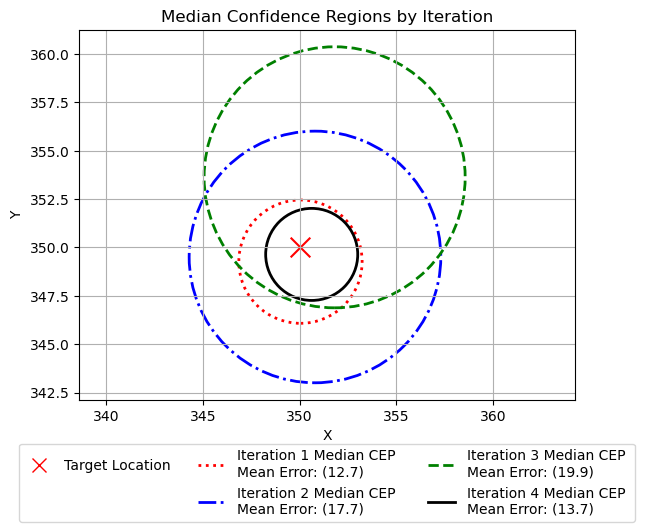

```python
# Plot Results

import matplotlib.pyplot as plt
from matplotlib.patches import Ellipse
from matplotlib.lines import Line2D
import numpy as np

ghost = plt.Line2D([], [], color='none', label='')

plt.scatter(350,350,color='red', label='Target Location', marker='x',s=200)

mean_num_steps = results_iter1['Num_Steps'].mean()
mean_median_error = results_iter1['Median_Error'].mean()
mean_median_cep = results_iter1['Median_CEP'].mean()
mean_median_x = results_iter1['Median_X'].mean()
mean_median_y = results_iter1['Median_Y'].mean()
mean_mad_x = results_iter1['MAD_X'].mean()
mean_mad_y = results_iter1['MAD_Y'].mean()

# Plot circle using MAD deviations of x & y values
radius = mean_median_cep
median_cep_legend1 = f'Iteration 1 Median CEP \nMean Error: ({np.round(mean_median_error,1)})'
circle_median = Ellipse((mean_median_x, mean_median_y), 2*radius, 2*radius, edgecolor='red', facecolor='none', linestyle=':', linewidth=2, label=median_cep_legend1)
plt.gca().add_patch(circle_median)

mean_num_steps = results_iter2['Num_Steps'].mean()
mean_median_error = results_iter2['Median_Error'].mean()
mean_median_cep = results_iter2['Median_CEP'].mean()
mean_median_x = results_iter2['Median_X'].mean()
mean_median_y = results_iter2['Median_Y'].mean()
mean_mad_x = results_iter2['MAD_X'].mean()
mean_mad_y = results_iter2['MAD_Y'].mean()

# Plot circle using MAD deviations of x & y values
radius = mean_median_cep
median_cep_legend2 = f'Iteration 2 Median CEP \nMean Error: ({np.round(mean_median_error,1)})'
circle_median = Ellipse((mean_median_x, mean_median_y), 2*radius, 2*radius, edgecolor='blue', facecolor='none', linestyle='-.', linewidth=2, label=median_cep_legend2)
plt.gca().add_patch(circle_median)

mean_num_steps = results_iter3['Num_Steps'].mean()
mean_median_error = results_iter3['Median_Error'].mean()
mean_median_cep = results_iter3['Median_CEP'].mean()
mean_median_x = results_iter3['Median_X'].mean()
mean_median_y = results_iter3['Median_Y'].mean()
mean_mad_x = results_iter3['MAD_X'].mean()
mean_mad_y = results_iter3['MAD_Y'].mean()

# Plot circle using MAD deviations of x & y values
radius = mean_median_cep
median_cep_legend3 = f'Iteration 3 Median CEP \nMean Error: ({np.round(mean_median_error,1)})'
circle_median = Ellipse((mean_median_x, mean_median_y), 2*radius, 2*radius, edgecolor='green', facecolor='none', linestyle='--', linewidth=2, label=median_cep_legend3)
plt.gca().add_patch(circle_median)

mean_num_steps = results_iter4['Num_Steps'].mean()
mean_median_error = results_iter4['Median_Error'].mean()
mean_median_cep = results_iter4['Median_CEP'].mean()
mean_median_x = results_iter4['Median_X'].mean()
mean_median_y = results_iter4['Median_Y'].mean()
mean_mad_x = results_iter4['MAD_X'].mean()
mean_mad_y = results_iter4['MAD_Y'].mean()

# Plot circle using MAD deviations of x & y values
radius = mean_median_cep
median_cep_legend4 = f'Iteration 4 Median CEP \nMean Error: ({np.round(mean_median_error,1)})'
circle_median = Ellipse((mean_median_x, mean_median_y), 2*radius, 2*radius, edgecolor='black', facecolor='none', linestyle='-', linewidth=2, label=median_cep_legend4)
plt.gca().add_patch(circle_median)

# Create custom legend entries for the line styles
legend_entries = [
    Line2D([0], [0], color='red', linestyle=':', linewidth=2, label=median_cep_legend1),
    Line2D([0], [0], color='blue', linestyle='-.', linewidth=2, label=median_cep_legend2),
    Line2D([0], [0], color='green', linestyle='--', linewidth=2, label=median_cep_legend3),
    Line2D([0], [0], color='black', linestyle='-', linewidth=2, label=median_cep_legend4)
]

# True Target Location
true_target = Line2D([0], [0], color='red', marker='x', markersize=10, linewidth=0, label='Target Location')

# Configure legend
plt.legend(
    handles=[true_target] +[ghost] + legend_entries,  # Combine the target and other legend entries
    loc='lower center',
    bbox_to_anchor=(0.5, -0.35),  # Adjust as necessary for your layout
    ncol=3,
    frameon=True
)

plt.xlabel('X')
plt.ylabel('Y')
plt.title('Median Confidence Regions by Iteration')
plt.grid(True)
plt.axis('equal')  # Equal aspect ratio
plt.show()
```

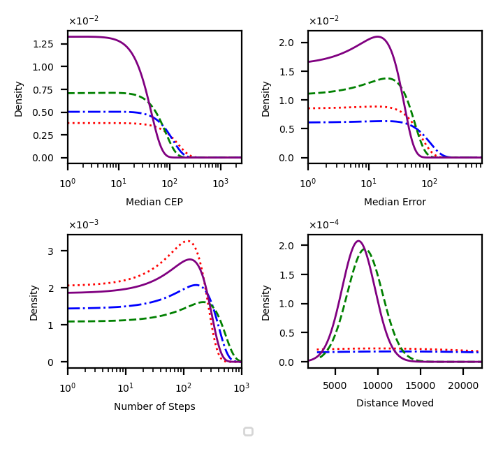

```python
import pandas as pd
import numpy as np
import matplotlib.pyplot as plt
from matplotlib import rcParams
from matplotlib.ticker import ScalarFormatter
from scipy.stats import norm

# Set global parameters for font size to ensure readability
rcParams.update({'font.size': 5, 'axes.labelsize': 5, 'axes.titlesize': 4, 'legend.fontsize': 5, 'xtick.labelsize': 5, 'ytick.labelsize': 5})

# Define dataset files and column types
dataset_files = [
    'iter1_results10000_fin.csv',
    'iter2_results10000_fin.csv',
    'iter3_1_bvm1_corr_results10000_fin.csv',
    'iter4_1_bvm1_corr_results10000_fin.csv'
]
data_columns = {
    'Median_CEP': 'Median CEP',
    'Median_Error': 'Median Error',
    'Num_Steps': 'Number of Steps',
    'Distance_Moved': 'Distance Moved'
}
colors = ['red', 'blue', 'green', 'purple']  # Different colors for each dataset
labels = ['Iteration 1', 'Iteration 2', 'Iteration 3', 'Iteration 4']  # Legend labels
linestyles = [':', '-.', '--', '-']  # Different linestyles for each dataset


# Setup a 2x2 subplot grid, figure size is set to fit 3.5 inches by 3 inches
fig, axes = plt.subplots(2, 2, figsize=(3.5, 3), dpi=200)  # Increase DPI for better resolution in small plots
axes = axes.flatten()

# This will hold the handles and labels for the legend
legend_handles = [None] * 4  # Pre-allocate a list for the handles


# Loop through each data type and plot on the corresponding subplot
for ax, (key, label) in zip(axes, data_columns.items()):
    for i, (file, color, leg_label) in enumerate(zip(dataset_files, colors, labels)):
        # Load data from each file
        data = pd.read_csv(file)
        values = data[key].values

        # Fit the normal distribution to the specified column
        mu, sigma = norm.fit(values)
        mu, sigma = round(mu), round(sigma)  # Round parameters to the nearest integer

        # Generate x values for plotting
        x = np.logspace(np.log10(max(1, np.min(values))), np.log10(np.max(values)), 1000)
        pdf_fitted = norm.pdf(x, mu, sigma)

        # Plot the fitted normal distribution for each dataset
        line, = ax.plot(x, pdf_fitted,  linestyle=linestyles[i], color=color, linewidth = 1)

        # Set the x-axis to logarithmic scale and dynamically set its limits based on the subplot
        if key == 'Distance_Moved':
            ax.set_xlim([np.min(values), np.max(values)])
            #val = 1

        else:
            ax.set_xlim([1, np.max(values)])
            ax.set_xscale('log')


        # Set formatter for y-axis
        formatter = ScalarFormatter(useMathText=True)
        formatter.set_scientific(True)
        formatter.set_powerlimits((-1, 1))  # Use scientific notation if exponent is greater than 1 or less than -1
        ax.yaxis.set_major_formatter(formatter)

    # Labels and title for each subplot
    ax.set_xlabel(label)
    ax.set_ylabel('Density')

# Place a single legend outside the bottom of the axes
fig.legend(handles=legend_handles, labels=labels, loc='upper center', bbox_to_anchor=(0.5, 0), ncol=4)

# Adjust layout to prevent overlap
plt.tight_layout()

# Show the plot
plt.show()
```